# Unlocking Guest Satisfaction: A Comprehensive Analysis of Airbnb Listings in New York City

Exploring the Impact of Listing Features and Geographic Location on Airbnb Guest Satisfaction

Authors: Junjie Wang; Wanhua Wang; Shuqing Yang; Jenny Zhong; Xinkang Zhang

Date: Sunday, April 28, 2024

[figure not shown]

# Final Project

## **Report**

### **Abstraction**

The continued rise in popularity of alternative accommodation platforms, Airbnb, presents the transformative shift in customer travel behavior. Travelers prioritize safety, trust, and quality of guest experience. Data-driven insights are essential for hosts to refine their listings and ensure they consistently exceed guest expectations. This study explores muti-factors that influence customer satisfaction on Airbnb, with a specific focus on the bustling metropolis of New York. We aim to discover the impact of different determinants. Specifically, how the geographic locations and overall listing performance affect the customer’s experience. Through a blend of principal component analysis, clustering analysis, regression models, text mining, and sentiment analysis, this research aims to reveal strategic adjustments for hosts, seeking to dissect the interplay between location-specific attributes and quality of listings. Ultimately, our goal is to gain a full-scale understanding of customer satisfaction drivers, providing actionable recommendations for optimization and improving the alignment of guest preferences with host offerings for a better travel experience.

### **Literature Review**

Amidst the expanding popularity of Airbnb, extensive research has been conducted on the preferences influencing customers’ accommodation choices. However, the combined influence of listing features and geographical factors on Airbnb guest satisfaction remains a notably under investigated area, highlighting a gap in understanding the comprehensive impact on consumer decisions.

In the realm of Airbnb, listing features such as price, amenities, location, and property type play a crucial role in shaping guest satisfaction. Studies have shown that these attributes significantly influence guest experiences and review scores (Guttentag et al., 2018). For example, the perceived value and quality of amenities can enhance guest satisfaction, while discrepancies in listing descriptions can lead to dissatisfaction (Xu & Li, 2016). Understanding the impact of these features is essential for hosts to optimize their listings and for researchers to develop models that accurately predict guest satisfaction.

Geographic location is another critical factor that influences guest satisfaction in Airbnb accommodations(Varma et al., 2016). Proximity to attractions, neighborhood characteristics, and regional differences play a significant role in shaping guest experiences (Kai Ding et al., 2021). Studies have found that guests prioritize locations that offer easy access to desired places and a favorable neighborhood environment (Sutherland & Kiatkawsin, 2020). Moreover, Kai Ding found that guests staying in lower-priced rooms are more concerned about the convenience of exploring the surrounding area, while those in higher-priced rooms prioritize the surrounding environment and interior facilities(Kai Ding et al., 2023). These insights contribute to a deeper understanding of the role of geographic factors in customer satisfaction and highlight the need for Airbnb hosts to consider these factors in their listings.

### **Research Question**

**Research Question 1:** How do listing features influence review score ratings, and what areas could be targeted for improvement?

*Null Hypothesis*

- Listing features do not significantly influence review score ratings.

*Alternative Hypothesis*

- Listing features significantly influence review score ratings, indicating areas of potential improvement.

This research question aims to investigate the impact of various listing features, specifically numeric variables, on review score ratings in the context of Airbnb listings in New York City. The analysis will focus solely on numeric factors such as **`price`**, **`amenity_count`**, **`cleaning_fee`**, **`verification_count`**, and **`cancellation_policy`**. To address this question, a multifaceted approach will be employed, including the use of gradient boosting machine (GBM) modeling, which incorporates numeric predictors to predict review score ratings. Additionally, feature importance analysis will be conducted to identify the most influential numeric factors affecting review score ratings. By understanding these factors, hosts can identify areas for improvement and enhance the overall guest experience.

**Research Question 2:** How does the geographic location of Airbnb listings impact customer satisfaction?

*Null Hypothesis*

- The geographic location of Airbnb listings does not significantly impact customer satisfaction.

*Alternative Hypothesis*

- The geographic location significantly impacts customer satisfaction, with variations across different neighborhoods.

The second research question aims to explore how the geographic location of Airbnb listings affects guest satisfaction. This includes examining the neighborhood of the listings, observable features between different neighborhoods, and the overall appeal of the area to guests. To investigate this, principal component analysis (PCA) and clustering analysis techniques will be employed. PCA will help identify underlying patterns and reduce the dimensionality of the review scores data, while clustering analysis, specifically K-means clustering, will group listings into clusters based on their satisfaction scores. Additionally, multivariate analysis of variance (MANOVA) will be conducted to determine whether there are statistically significant differences in satisfaction scores among different neighborhoods. This comprehensive analysis will shed light on the relationship between listing location and customer preferences, offering valuable insights for hosts and platform administrators.

### **Raw Data Description**

We selected datasets of Airbnb listings and customer reviews from Kaggle as our data sources for investigating our research problem. These datasets contain detailed information on each listing, including host details, property features, and the rating and comments provided by customers.

According to our research questions, property characteristics, host information, and geographical attributes are the most relevant information in analyzing each listing. Property characteristics include property type, room type, accommodation capacity, and amenities. Host-related information includes host identifiers, verifications, response metrics, and hosting history. Although our focus is on New York listings, geographic details such as neighborhood information and location coordinates are also included. These datasets enable us to assess the relevance of factors influencing customer satisfaction levels.

While the **`comments`** field in the raw *`review`* dataset may appear messy, it holds significant importance for our sentiment analysis. Customer survey data encompasses overall review scores and specific ratings for various aspects of their stay, such as cleanliness, description accuracy, and communication. These comprehensive datasets offer broad information about Airbnb listings and provide ample support for further in-depth analysis.

### **Data Cleaning Process**

The data cleaning process involved several conscious steps to ensure the integrity, consistency, and reliability of the dataset. We treat this as one of the most important phrases as this will be the foundation for further analyses.

Initially, an overview of the *`review`* and *`listing`* datasets was conducted using essential functions like **`glimpse()`**, **`str()`**, **`head()`**, and **`dim()`**. This initial examination provided insights into the structure, dimensions, and variable types of the datasets, guiding subsequent cleaning procedures. In the *`review`* dataset, only the relevant columns (**`listing_id`** and **`comments`**) were retained, streamlining further cleaning processes.

It was observed that the **`comments`** column contained non-English text, necessitating a language detection process. Despite its time-intensive nature (approximately 80 to 120 minutes), this step was crucial for subsequent text mining analyses. Following language detection and filtering English-only comments, comments were grouped by **`listing_id`** and combined into a single string using **`summarize()`** and **`paste()`** functions. Simultaneously, stop words were removed from the combined comments to eliminate common language elements without significant semantic meaning, facilitated by **`unnest_tokens()`** and **`anti_join()`** functions.

Turning to the *`listing`* dataset, missing values were addressed using various strategies based on domain knowledge, missing percentage, and variable importance. Predictive modeling, replacement with predetermined values, and removal of rows with missing values were among the employed strategies. Data type transformations and formatting adjustments ensure consistency across the dataset, leveraging string manipulation functions like **`str_replace()`** and **`as.numeric()`**. Additionally, tokenization was performed on the **`amenities`** column to identify common feature offerings by hosts, followed by the creation of binary indicators(dummy variables) using **`mutate()`** and regular expression matching with **`str_detect()`**.

Finally, the two datasets (*`review`* and *`listing`*) were merged into a single dataset named *`airbnb`* using the **`inner_join()`** function, linking listings based on their unique identifiers(**`id`** and **`listing_id`**). A comprehensive check for missing values was then conducted using the **`colSums()`** function on the final *`airbnb`* dataset, ensuring data structure and completeness.

For the fact that not all attributes may be utilized for subsequent data analysis, the missing values leftover were retained in their current state. This decision was made to preserve as many observations as possible. It is worth noting that the **`colSums()`** function will be applied before each subsequent analysis to determine whether additional cleaning processes are necessary, ensuring ongoing data quality assessment and refinement.

### **Techniques Chosen**

R Studio will be our programming language because of its specialized features for data analysis. It provides powerful tools for manipulating diverse and unstructured data, along with a wide range of statistical packages for conducting detailed analysis. R Studio’s visualization capabilities allow us to create various graphs and charts, enabling clear and impactful presentation of our findings.

For our first research question, we will utilize predictive data modeling to quantify how listing features influence review score ratings. This approach is chosen to provide hosts with actionable insights to enhance guest satisfaction. Models like GBM are adept at capturing complex interactions between variables and can predict review scores even with non-linear relationships in the data. Additionally, these models offer feature importance analysis, aiding in the identification of key factors influencing guest satisfaction. Understanding these relationships will enable hosts to optimize their listings, potentially improving competitiveness in the marketplace.

For our second research question, we will utilize Principal Component Analysis (PCA) to condense the various review score metrics into key components. This method will help identify factors impacting customer satisfaction by revealing underlying patterns in the data. Additionally, PCA simplifies visualization and understanding of significant factors while reducing issues like multicollinearity among variables.

Moreover, on the basis of PCA results, we will employ clustering to segment the data into meaningful groups without prior labeling. This approach will assist in identifying natural groupings in the Airbnb dataset, such as types of listings or customer preferences based on satisfaction scores. Clustering will enable us to tailor improvement strategies for hosts and understand how different types of listings perform across various neighborhoods, aiding strategic decision-making for property management and marketing.

Additionally, we will employ text mining techniques to extract insights from textual data like reviews and amenities, to uncover trends and sentiments that influence satisfaction levels. By text mining from unstructured data, hosts can better understand guest sentiments, identify common issues, and gain qualitative insights into customer satisfaction.

Finally, sentiment analysis will be crucial in our study to analyze the emotional tone of reviews left by Airbnb guests. Techniques such as AFINN, Bing, and NRC will be used to extract sentiment scores/segments from customer comments, providing an overview of guest feedback. These methods will analyze natural language and identify whether sentiments expressed are positive, negative, or neutral. Insights gained from sentiment analysis will complement quantitative data, offering a holistic view of guest experiences.

### **Analytical Results**

#### **Text Mining Results**

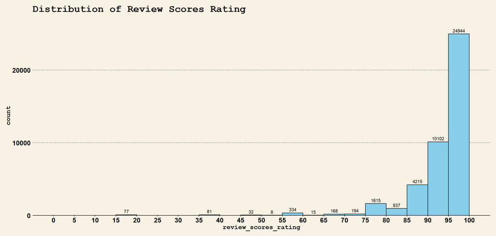

We also investigated the customer sentiment using the Afinn sentiment analysis, which assigned scores to each review.

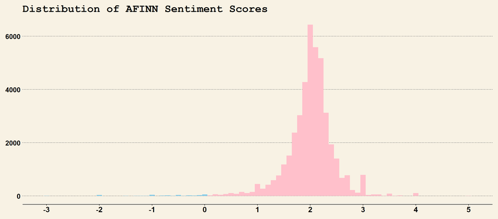

These scores were correlated with the review scores, revealing a moderate correlation coefficient of 0.4397068. This suggests that customers’ sentiment in text reviews is somewhat reflective of their numerical ratings.

```r
cor(airbnb$review_scores_rating, airbnb$afinn)
```

```
## [1] 0.4397068
```

In addition, we utilized text mining to analyze the distribution of sentiments categorized by Bing. The findings showed that the vast majority of reviews possess a positive sentiment.

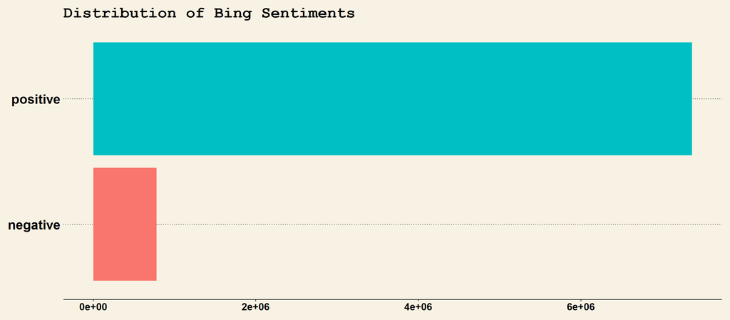

A more detailed visualization of the NRC sentiment analysis results highlighted that reviews tend to evoke emotions such as **`trust`**, **`joy`**, **`anticipation`**, and **`surprise`** more frequently than negative emotions like **`sadness`**, **`fear`**, **`anger`**, and **`disgust`**. Therefore, in the visualization, we see a greater prominence of positive sentiments compared to negative ones, reflecting the overall positivity of the customer experiences

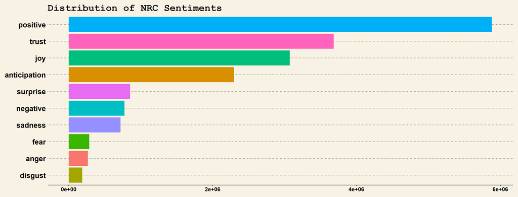

Our research also included an evaluation of customer satisfaction across different neighborhoods in New York. The metrics considered for the mean satisfaction score included description accuracy, check-in process, cleanliness, communication, location, overall rating, and value. The findings indicated that Staten Island stood out as the neighborhood with the highest level of overall satisfaction. In contrast, as a tourist and business hub, Manhattan earned the highest mean score for location, aligning with our expectations.

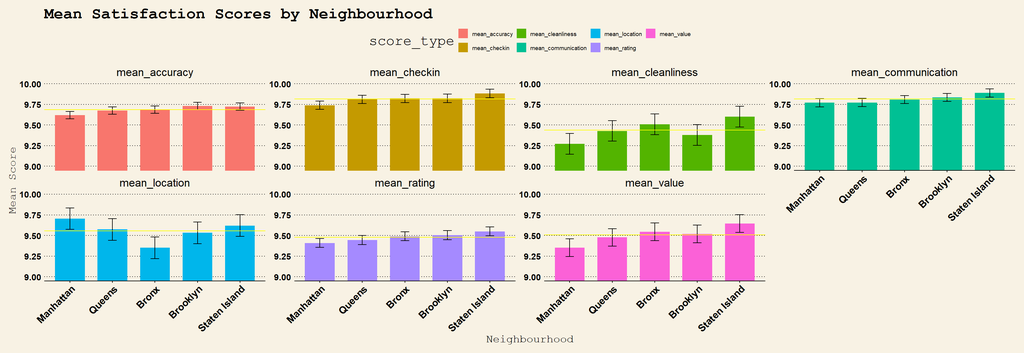

#### **PCA & Clustering Analysis Results**

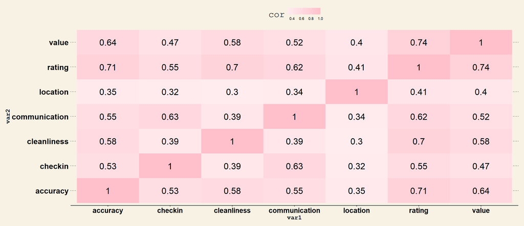

##### **PCA Analysis**

Dive into PCA analysis, from the scree plot, we believe the first three principal components captured a substantial amount of the total variance in the data.

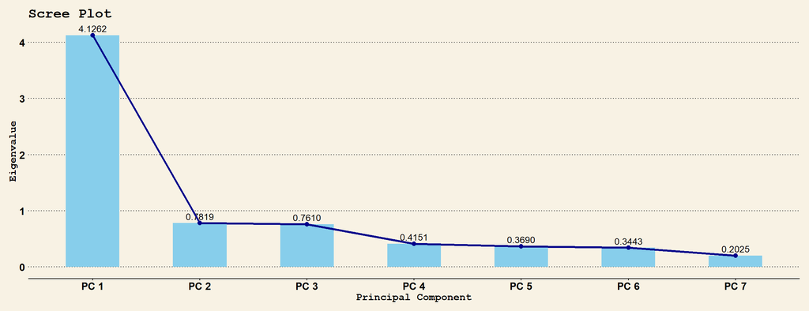

The PCA analysis with three components indicates that the first component explains 58.95% of the variance, the second component explains 11.17%, and the third component explains 10.87%, arriving a 80.99% cumulative variance explained.

|  | eigenvalue | percentage of variance | cumulative percentage of variance |
| --- | --- | --- | --- |
| comp 1 | 4.12623144827107 | 58.94616354669945 | 58.94616354669945 |
| comp 2 | 0.7818584948586211 | 11.16940706940317 | 70.11557061610262 |
| comp 3 | 0.761030794315033 | 10.8718684902092 | 80.98743910631181 |
| comp 4 | 0.4150573465290779 | 5.929390664698084 | 86.9168297710099 |
| comp 5 | 0.3690305067071344 | 5.271864381527798 | 92.18869415253769 |
| comp 6 | 0.3443307473333622 | 4.919010676188375 | 97.10770482872607 |
| comp 7 | 0.2024606619892781 | 2.892295171273924 | 99.99999999999999 |

Examination of variable contributions reveals that overall_rating, accuracy, and value contribute significantly to the first component, while cleanliness, location, check-in and communication contribute more to the second component. The third component could suggest that customers’ perceptions of Airbnb listings’ locations significantly impact their satisfaction levels. The location value not limited to the neighborhood level, may also related to the convenience or close to stores and transportation. This component reflecting variations in review scores associated with location differences. This analysis provides insights into the underlying structure of the review scores and the variables driving the observed patterns.

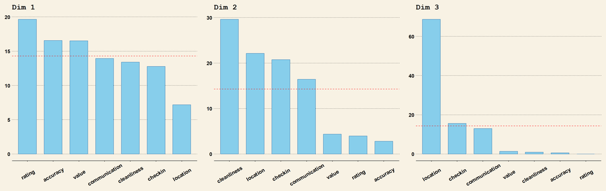

In conclusion, the substantial loading of the location variable in the third principal component of the PCA results (68.67) confirms its significant influence on the dataset’s variability. This aligns with moderate correlations (0.3 to 0.41) found between location and other rating metrics. Together, these findings highlight the pivotal role of location in shaping customer ratings, emphasizing its importance in the Airbnb experience.

|  | Dim.1 | Dim.2 | Dim.3 |
| --- | --- | --- | --- |
| rating | 19.63 | 3.96 | 0 |
| accuracy | 16.57 | 2.78 | 0.55 |
| cleanliness | 13.41 | 29.6 | 0.91 |
| checkin | 12.78 | 20.74 | 15.58 |
| communication | 13.92 | 16.41 | 12.95 |
| location | 7.19 | 22.14 | 68.67 |
| value | 16.5 | 4.36 | 1.34 |

##### **Clustering Analysis**

In clustering analysis, we applied k-means clustering to principal components derived from PCA to explore dimensionality’s impact on clustering outcomes. Clustering based on two principal components showed distinct, well-separated clusters, while clustering based on three components exhibited increased overlap, indicating reduced separability and greater complexity. This highlights the critical role of dimensionality selection in further analysis.

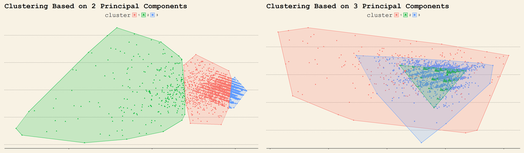

Additionally, our previous findings(in PCA) regarding the significant influence of location_review variable on dataset variability align with the observed overlap in clusters dominated by location_review feature. The multifaceted nature of location feature such as proximity to transportation, safety considerations, and cultural nuances, introduces complexity, potentially leading to similar patterns across different clusters and contributing to observed overlaps.

We then performed k-means clustering based on two principal components by PCA, establishing three clusters. Cluster 1 had the largest size with 32336 listings, followed by Cluster 3 with 9650, and Cluster 2 as the smallest with 736 listings.

```
##
##     1     2     3
## 32336   736  9650
```

Followed by a comprehensive analysis of each cluster based on various metrics. Clusters are characterized by average ratings across different aspects such as accuracy, cleanliness, check-in, communication, location, and value. Additionally, the summary includes the distribution of listings across different neighborhoods within each cluster. Observed that cluster 1 outperformed the others, showing the highest mean ratings across all evaluation elements. In comparison, cluster 2 fall behind and needs further improvements on customer experiences

It is worth noting that the average AFINN score across clusters aligns with the observed cluster characteristics, indicating the sentiment polarity of reviews within each cluster. This consistency suggests that the sentiment expressed in reviews corresponds to the different ratings metrics within each cluster. By considering sentiment analysis alongside other metrics, such as ratings and neighborhood distributions, we can gain a more comprehensive understanding of the factors driving customer satisfaction and preferences within each cluster.

|  | cluster | avg_rating | avg_accuracy | avg_cleanliness | avg_checkin | avg_communication | avg_location | avg_value | avg_afinn | count_Bronx | count_Brooklyn | count_Manhattan | count_Queens | count_Staten_Island |
| --- | --- | --- | --- | --- | --- | --- | --- | --- | --- | --- | --- | --- | --- | --- |
| 1 | 1 | 97.3082 | 9.9377 | 9.6754 | 9.956 | 9.9682 | 9.7437 | 9.7262 | 2.0799 | 934 | 14483 | 12308 | 4296 | 315 |
| 2 | 2 | 57.8533 | 6.5326 | 5.7908 | 7.2826 | 7.0571 | 7.9307 | 6.0285 | 0.8916 | 14 | 256 | 355 | 109 | 2 |
| 3 | 3 | 88.2465 | 9.0451 | 8.5241 | 9.4172 | 9.443 | 9.2554 | 8.7744 | 1.7957 | 275 | 3578 | 4495 | 1253 | 49 |

```
##                  Df   Pillai approx F num Df den Df    Pr(>F)
## neighbourhood     4 0.051789   80.041     28 170856 < 2.2e-16 ***
## Residuals     42717
## ---
## Signif. codes:  0 '***' 0.001 '**' 0.01 '*' 0.05 '.' 0.1 ' ' 1
```

#### **GBM Modeling Results**

After running the gradient boosting machine (GBM) predictive modeling and extracting feature importance, it’s evident that features such as price and amenity_count play a significant role in predicting review scores ratings. The top features identified by the GBM model provide valuable insights into the factors influencing review scores. This information can guide hosts and property managers in making targeted improvements to enhance the guest experience and overall satisfaction.

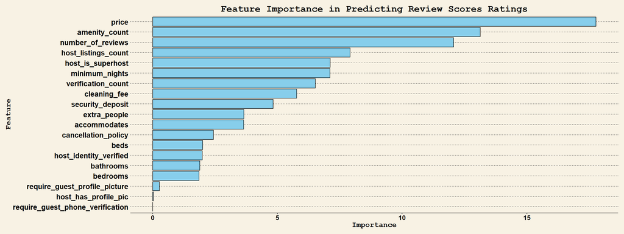

### **Recommendations**

##### **Research Question 1**

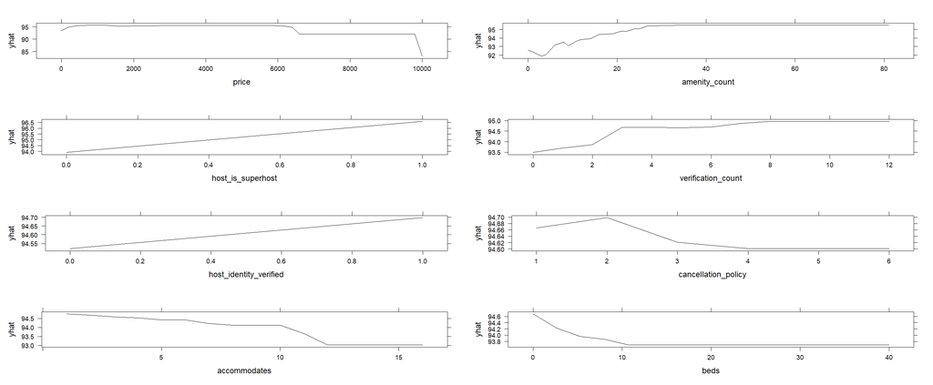

##### **Research Question 2**

Exploring the impact of geographic location on Airbnb guest satisfaction, our PCA and clustering analysis identify that Cluster 1, predominantly encompassing listings from Manhattan and Brooklyn, outperforms other areas with all aspects, especially accuracy, communication, and check-in experiences.

Recap of cluster_summary datatable here:

|  | cluster | avg_rating | avg_accuracy | avg_cleanliness | avg_checkin | avg_communication | avg_location | avg_value | avg_afinn | count_Bronx | count_Brooklyn | count_Manhattan | count_Queens | count_Staten_Island |
| --- | --- | --- | --- | --- | --- | --- | --- | --- | --- | --- | --- | --- | --- | --- |
| 1 | 1 | 97.3082 | 9.9377 | 9.6754 | 9.956 | 9.9682 | 9.7437 | 9.7262 | 2.0799 | 934 | 14483 | 12308 | 4296 | 315 |
| 2 | 2 | 57.8533 | 6.5326 | 5.7908 | 7.2826 | 7.0571 | 7.9307 | 6.0285 | 0.8916 | 14 | 256 | 355 | 109 | 2 |
| 3 | 3 | 88.2465 | 9.0451 | 8.5241 | 9.4172 | 9.443 | 9.2554 | 8.7744 | 1.7957 | 275 | 3578 | 4495 | 1253 | 49 |

Conversely, listings belonging cluster 2 have a relatively low rating metrics, suggesting bad customer experiences and provide improvement recommendations areas for hosts. This conclusion is further supported by the sentiment analysis on cluster 2 listings.

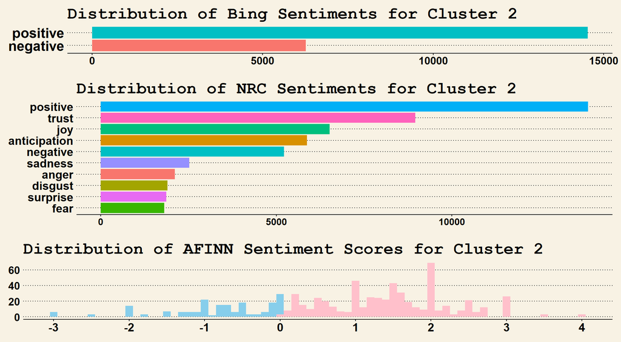

```
##                  Df   Pillai approx F num Df den Df    Pr(>F)
## neighbourhood     4 0.051789   80.041     28 170856 < 2.2e-16 ***
## Residuals     42717
## ---
## Signif. codes:  0 '***' 0.001 '**' 0.01 '*' 0.05 '.' 0.1 ' ' 1
```

##### **Additional analysis - Beyond RQ**

In the continuation of our investigation for RQ2, we delved deeper into the amenities offered by conducting text mining analysis of the top 20 amenities across different clusters. Our analysis indicates that Cluster 1 listings prominently feature amenities such as hair dryers, (pets)friendly, Wi-Fi, and smoke detectors, which are valued by guests.

These findings imply that equipping lower-rated Airbnb with popular amenities may strengthen its potential to improve customer satisfaction level. However, further investigations are required to test our assumptions.

|  | cluster | workspace | wifi | tv | smoke | shampoo | monoxide | laptop | kitchen | iron | hot | heating | hangers | hair | friendly | essentials | dryer | detector | conditioning | carbon | air |
| --- | --- | --- | --- | --- | --- | --- | --- | --- | --- | --- | --- | --- | --- | --- | --- | --- | --- | --- | --- | --- | --- |
| 1 | 1 | 0.6935 | 1.0037 | 1.0198 | 0.9031 | 0.73 | 0.757 | 0.6935 | 0.917 | 0.6839 | 0.6801 | 0.9555 | 0.7892 | 0.7184 | 1.0059 | 0.9525 | 1.1227 | 1.6601 | 0.8866 | 0.757 | 0.8868 |
| 2 | 2 | 0.5489 | 0.9348 | 0.7758 | 0.7948 | 0.5 | 0.5489 | 0.5489 | 0.8628 | 0.3886 | 0.4144 | 0.8791 | 0.5815 | 0.4239 | 0.7758 | 0.8125 | 0.7378 | 1.3438 | 0.7228 | 0.5489 | 0.7228 |
| 3 | 3 | 0.5913 | 0.9915 | 0.9366 | 0.8353 | 0.6338 | 0.6642 | 0.5913 | 0.9076 | 0.5674 | 0.5755 | 0.9417 | 0.6966 | 0.5839 | 0.9267 | 0.9038 | 0.9109 | 1.4996 | 0.8393 | 0.6642 | 0.8396 |

Based on these insights, we recommend that hosts consider the strategic addition or promotion of these amenities to boost guest satisfaction. Specifically, from the chart below, we can observe that the average occurrence of top amenities has a clear difference across three clusters. Which further proposed the recommendations for hosts to take the top amenities into account, approaching to the desired cluster and attracting more customers, potentially, receiving higher review scores.

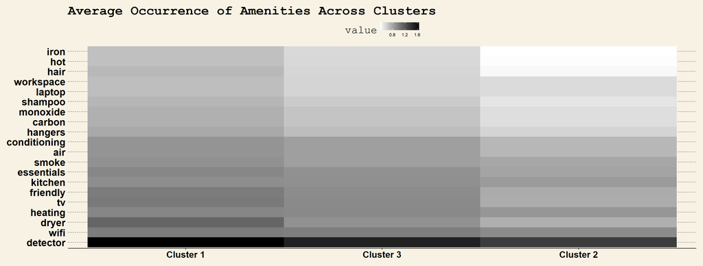

Lastly, our price prediction model using XGBoost highlights the potential overpriced listings, which may impact on booking rates and, subsequently, on review scores. Some listings showed a variance between the predicted and actual prices. We suggest that hosts calibrate their pricing strategies to avoid overestimating their listing value, which could deter potential guests and affect occupancy rates. A competitive and accurate pricing approach may facilitate quicker bookings and lead to improved guest satisfaction.

The datatable below shows the listings that are potentially overpriced, suggesting to reduce the listing prices to align with the competitive market.

|  | id | price | prediction | overprice |
| --- | --- | --- | --- | --- |
| 1 | 10085478 | 299 | 253.4451599121094 | 45.55484008789062 |
| 2 | 10154444 | 135 | 88.27656555175781 | 46.72343444824219 |
| 3 | 10319494 | 250 | 203.6598815917969 | 46.34011840820312 |
| 4 | 13004967 | 220 | 128.9415435791016 | 91.05845642089844 |
| 5 | 1301321 | 1899 | 1820.105224609375 | 78.894775390625 |
| 6 | 13070577 | 350 | 248.2053985595703 | 101.7946014404297 |
| 7 | 1356710 | 199 | 126.7750244140625 | 72.2249755859375 |
| 8 | 14339989 | 275 | 189.9143218994141 | 85.08567810058594 |
| 9 | 14408114 | 2500 | 2430.502685546875 | 69.497314453125 |
| 10 | 14471418 | 650 | 587.001953125 | 62.998046875 |

[output cut: 86 more lines]

### **Conclusion**

This research has thoroughly investigated the factors influencing Airbnb guest satisfaction in New York City, focusing on listing features and geographic factors, revealing the impacts of these factors on Airbnb’s guest experience and review scores.

Advanced analytical techniques (like clustering, PCA, and sentiment analysis) provides insightful information, indicating the importance of location in guest satisfaction, and helps to comprehend consumer’s preferences and emotions. Through this study, the gap in existing research can be filled. Besides, it gives some helpful suggestions to hosts, which will help them to enhance their listings, utilize pricing strategies based on the market, and boost booking rates and guest satisfaction.

In summary, this study highlights that data-driven strategies can greatly influence the hospitality industry. Moreover, it suggests that Airbnb hosts can enhance competitiveness and align with guest expectations through this data. Based on this research, future research and continuous improvements in shared accommodation can achieve great development.

## **Uncleaned Data**

[Click to the Review Dataset](https://drive.google.com/file/d/1JJF1bX_UgiIKmEIC_ySKHgbJzb1NbmYP/view?usp=drive_link)

[Click to the Listing Dataset](https://drive.google.com/file/d/1njyKR_Cs7qjjK4l-lH7ST2RUGCbD5pgB/view?usp=drive_link)

#### **`review` Dataset Structure Overview**

```
## Rows: 1,110,024
## Columns: 6
## $ listing_id    <dbl> 2595, 2595, 2595, 2595, 2595, 2595, 2595, 2595, 2595, 25…
## $ id            <dbl> 17857, 19176, 19760, 34320, 46312, 1238204, 1293632, 202…
## $ date          <chr> "2009-11-21", "2009-12-05", "2009-12-10", "2010-04-09", …
## $ reviewer_id   <int> 50679, 53267, 38960, 71130, 117113, 1783688, 1870771, 21…
## $ reviewer_name <chr> "Jean", "Cate", "Anita", "Kai-Uwe", "Alicia", "Sergey", …
## $ comments      <chr> "Notre séjour de trois nuits.\n<br/>Nous avons apprécier…
```

#### **`review` Dataset Missing Values**

```
## comments
##       40
```

#### **`listing` Dataset Structure Overview**

```
## Rows: 153,254
## Columns: 106
## $ id                                           <int> 2595, 3831, 5099, 5121, 5…
## $ listing_url                                  <chr> "https://www.airbnb.com/r…
## $ scrape_id                                    <dbl> 2.020021e+13, 2.020021e+1…
## $ last_scraped                                 <chr> "2020-02-12", "2020-02-13…
## $ name                                         <chr> "Skylit Midtown Castle", …
## $ summary                                      <chr> "Beautiful, spacious skyl…
## $ space                                        <chr> "- Spacious (500+ft²), im…
## $ description                                  <chr> "Beautiful, spacious skyl…
## $ experiences_offered                          <chr> "none", "none", "none", "…
## $ neighborhood_overview                        <chr> "Centrally located in the…
## $ notes                                        <chr> "", "", "Read My Full Lis…
## $ transit                                      <chr> "Apartment is located on …
## $ access                                       <chr> "Guests have full access …
```

[output cut: 93 more lines]

#### **`listing` Dataset Missing Values**

```
##               thumbnail_url                  medium_url
##                      153254                      153254
##              xl_picture_url         host_listings_count
##                      153254                         204
##   host_total_listings_count                   bathrooms
##                         204                         150
##                    bedrooms                        beds
##                         220                        1033
##                 square_feet        review_scores_rating
##                      152103                       33881
##      review_scores_accuracy   review_scores_cleanliness
##                       33984                       33942
##       review_scores_checkin review_scores_communication
##                       34023                       33975
##      review_scores_location         review_scores_value
##                       34032                       34032
##           reviews_per_month
##                       30965
```

## **Cleaned Data**

[Click to the Cleaned Airbnb Dataset](https://drive.google.com/file/d/14VkL8L2GGymUZitMySlbxOuICZJ4fiWL/view?usp=drive_link)

#### **This page only shows the first 1000 rows of data for overview**

- Few variables are truncated in datatable for tidy purpose

|  | id | name | description | host_name | host_since | host_location | host_response_time | host_response_rate | host_acceptance_rate | host_is_superhost | host_neighbourhood | host_listings_count | host_verifications | host_has_profile_pic | host_identity_verified | city | zipcode | property_type | room_type | accommodates | bathrooms | bedrooms | beds | amenities | price | weekly_price | monthly_price | security_deposit | cleaning_fee | … |
| --- | --- | --- | --- | --- | --- | --- | --- | --- | --- | --- | --- | --- | --- | --- | --- | --- | --- | --- | --- | --- | --- | --- | --- | --- | --- | --- | --- | --- | --- | --- |
| 1 | 2595 | Skylit Midtown Castle | Beautiful, spacious skylit studio in the heart of Midtown... | Jennifer | 2008-09-09 | New York, New York, United States | within a day | 50 | 38 | false | Midtown | 6 | ['email', 'phone', 'reviews', 'offline_government_id', 'k... | true | true | New York | 10018 | Apartment | Entire home/apt | 1 | 1 | 0 | 1 | {TV,Wifi,"Air conditioning",Kitchen,"Paid parking off pre... | 225 | 1995 |  | 350 | 95 | … |
| 2 | 5121 | BlissArtsSpace! | HELLO EVERYONE AND THANKS FOR VISITING BLISS ART SPACE! ... | Garon | 2009-02-03 | New York, New York, United States |  |  | 67 | false | Bedford-Stuyvesant | 1 | ['email', 'phone', 'facebook', 'reviews', 'offline_govern... | true | false | Brooklyn | 11216 | Apartment | Private room | 2 | 0 | 1 | 1 | {Wifi,"Air conditioning",Kitchen,"Pets live on this prope... | 60 |  |  | 450 | 0 | … |
| 3 | 5178 | Large Furnished Room Near B'way | Please don’t expect the luxury here just a basic room in ... | Shunichi | 2009-03-03 | New York, New York, United States | within a few hours | 90 | 100 | false | Hell's Kitchen | 1 | ['email', 'phone', 'facebook', 'reviews'] | true | false | New York | 10019 | Apartment | Private room | 2 | 1 | 1 | 1 | {TV,Wifi,"Air conditioning","Paid parking off premises","... | 79 | 470 |  |  | 15 | … |
| 4 | 5203 | Cozy Clean Guest Room - Family Apt | Our best guests are seeking a safe, clean, spare room in ... | MaryEllen | 2009-02-05 | New York, New York, United States |  |  |  | false | Upper West Side | 1 | ['email', 'phone', 'facebook', 'google', 'reviews', 'jumi... | true | true | New York | 10025 | Apartment | Private room | 1 | 1 | 1 | 1 | {Internet,Wifi,"Air conditioning","Paid parking off premi... | 79 |  |  |  |  | … |
| 5 | 5803 | Lovely Room 1, Garden, Best Area, Legal rental | Beautiful house, gorgeous garden, patio, cozy room, and h... | Laurie | 2009-03-10 | New York, New York, United States | within a few hours | 90 | 99 | true | Park Slope | 3 | ['email', 'phone', 'facebook', 'reviews', 'jumio', 'offli... | true | true | Brooklyn | 11215 | Townhouse | Private room | 2 | 1.5 | 1 | 0 | {Internet,Wifi,"Air conditioning","Free street parking",H... | 89 |  |  | 200 | 67 | … |
| 6 | 6848 | Only 2 stops to Manhattan studio | Comfortable studio apartment with super comfortable king ... | Allen &amp; Irina | 2009-05-06 | New York, New York, United States | within an hour | 100 | 97 | false | Williamsburg | 1 | ['email', 'phone', 'reviews', 'offline_government_id', 's... | true | false | Brooklyn | 11211 | Apartment | Entire home/apt | 3 | 1 | 1 | 1 | {TV,Wifi,"Air conditioning",Kitchen,"Free street parking"... | 140 |  |  | 200 | 90 | … |
| 7 | 7097 | Perfect for Your Parents + Garden | This is a street-level floor of a 4-story brownstone on a... | Jane | 2009-05-17 | New York, New York, United States | within an hour | 100 | 100 | true | Fort Greene | 1 | ['email', 'phone', 'reviews', 'offline_government_id', 'k... | true | true | Brooklyn | 11205 | Apartment | Entire home/apt | 4 | 1 | 1 | 2 | {TV,"Cable TV",Internet,Wifi,"Air conditioning",Kitchen,"... | 199 |  |  | 250 | 30 | … |
| 8 | 7801 | Sweet and Spacious Brooklyn Loft | A true open-plan loft in a repurposed factory building wi... | Chaya | 2009-06-12 | New York, New York, United States |  |  | 0 | false | Williamsburg | 1 | ['email', 'phone', 'reviews', 'kba'] | true | true | Brooklyn | 11211 | Loft | Entire home/apt | 4 | 1 | 1 | 2 | {TV,"Cable TV",Internet,Wifi,"Air conditioning",Kitchen,"... | 299 |  |  | 300 | 120 | … |
| 9 | 8490 | MAISON DES SIRENES1,bohemian apartment | I am the lucky owner of an amazing brownstone. I have bee... | Nathalie | 2009-07-10 | New York, New York, United States | within an hour | 100 | 100 | false | Bedford-Stuyvesant | 2 | ['email', 'phone', 'reviews', 'jumio', 'government_id'] | true | true | Brooklyn | 11216 | Loft | Entire home/apt | 5 | 1 | 1 | 4 | {TV,"Cable TV",Wifi,"Air conditioning",Kitchen,"Free stre... | 120 | 1000 | 3500 | 300 | 90 | … |
| 10 | 9704 | Spacious 1 bedroom in luxe building | The room is spacious, the neighborhood is safe, and you a... | Teri | 2009-08-16 | US | within a day | 67 | 43 | false | Harlem | 1 | ['email', 'phone', 'reviews', 'jumio', 'offline_governmen... | true | true | New York | 10027 | Apartment | Private room | 2 | 1 | 1 | 1 | {TV,"Cable TV",Internet,Wifi,"Air conditioning",Kitchen,E... | 52 |  | 1700 | 150 | 50 | … |

[output cut: 990 more lines]

#### **`airbnb` Dataset Overview by `glimpse()` Function**

```
## Rows: 43,182
## Columns: 65
## $ id                               <int> 2595, 5121, 5178, 5203, 5803, 6848, 7…
## $ name                             <chr> "Skylit Midtown Castle", "BlissArtsSp…
## $ description                      <chr> "Beautiful, spacious skylit studio in…
## $ host_name                        <chr> "Jennifer", "Garon", "Shunichi", "Mar…
## $ host_since                       <chr> "2008-09-09", "2009-02-03", "2009-03-…
## $ host_location                    <chr> "New York, New York, United States", …
## $ host_response_time               <chr> "within a day", NA, "within a few hou…
## $ host_response_rate               <int> 50, NA, 90, NA, 90, 100, 100, NA, 100…
## $ host_acceptance_rate             <int> 38, 67, 100, NA, 99, 97, 100, 0, 100,…
## $ host_is_superhost                <chr> "false", "false", "false", "false", "…
## $ host_neighbourhood               <chr> "Midtown", "Bedford-Stuyvesant", "Hel…
## $ host_listings_count              <int> 6, 1, 1, 1, 3, 1, 1, 1, 2, 1, 0, 3, 2…
## $ host_verifications               <chr> "['email', 'phone', 'reviews', 'offli…
```

[output cut: 52 more lines]

## **Working R Code**

#### **Packages Import**

```r
library(tidyverse)
library(tidytext)
library(tm)
library(SnowballC)
library(magrittr)
library(tidytext)
library(ggthemes)
library(wordcloud)
library(lsa)
library(rpart)
library(rpart.plot)
library(lm.beta)
library(caret)
library(DT)
library(scales)
library(gridExtra)
library(rstatix)
library(FactoMineR)
library(factoextra)
library(cluster)
library(psych)
library(dendextend)
library(xgboost)
library(rsample)
library(randomForest)
library(gbm)
library(e1071)
library(pls)
library(mgcv)
library(pdp)
```

#### **Data Loading**

```r
# Loading & Exploring Dataset
airbnb <- read_csv("Cleaned_airbnb_dataset.csv")
glimpse(airbnb)
head(airbnb, 10)

table(airbnb$property_type)
table(airbnb$room_type)
table(airbnb$cancellation_policy)
table(airbnb$neighbourhood)

# Convert 'neighbourhood' to factor
airbnb$neighbourhood <- factor(airbnb$neighbourhood)
airbnb$cancellation_policy <- factor(airbnb$cancellation_policy)
airbnb$room_type <- factor(airbnb$room_type)

airbnb <- airbnb %>%
  mutate(security_deposit = ifelse(is.na(security_deposit), 0, security_deposit),
         cleaning_fee = ifelse(is.na(cleaning_fee), 0, cleaning_fee))

# Remove unnecessary columns
airbnb <- airbnb[, -which(names(airbnb) %in% c('city', 'zipcode', 'weekly_price',
               'monthly_price', 'name',
               'description', 'host_location', 'host_response_time',
               'host_response_rate', 'host_acceptance_rate',
               'host_neighbourhood', 'guests_included', 'maximum_nights',
               'number_of_reviews_ltm', 'host_name'))]


# Check NA values
colSums(is.na(airbnb))[colSums(is.na(airbnb)) != 0]
# Check column names
colnames(airbnb)

glimpse(airbnb)
```

#### **General Analysis**

```r
# Review text mining for sentiment score
# Afinn sentiment analysis
afinn <- airbnb %>%
  select(id, review_scores_rating, comments) %>%
  unnest_tokens(input = comments, output = word) %>%
  inner_join(get_sentiments('afinn')) %>%
  group_by(id, review_scores_rating) %>%
  summarize(afinn = mean(value))
afinn

# Add Afinn score to the airbnb dataset
airbnb <- merge(airbnb, afinn, by = c("id", "review_scores_rating"))

# Correlation between review_score and afinn_score
cor(airbnb$review_scores_rating, airbnb$afinn)



# Sentiment Distribution Plotting
# Distribution of NRC Sentiments
bing_distribution_plot <- airbnb%>%
  mutate(row_group = row_number()) %>%
  group_by(row_group) %>%
  unnest_tokens(output = word, input = comments) %>%
  inner_join(get_sentiments('bing')) %>%
  group_by(sentiment) %>%
  count() %>%
  ggplot(aes(x = sentiment, y = n, fill = sentiment)) +
  geom_col() +
  guides(fill = F) +
  coord_flip() +
  theme_wsj() +
  theme(axis.text.x = element_text(angle = 0, size = 18),
        axis.text.y = element_text(size = 24)) +
  labs(title = "Distribution of Bing Sentiments")
bing_distribution_plot

# Distribution of NRC Sentiments
nrc_distribution_plot <- airbnb%>%
  mutate(row_group = row_number()) %>%
  group_by(row_group) %>%
  unnest_tokens(output = word, input = comments) %>%
  inner_join(get_sentiments('nrc')) %>%
  group_by(sentiment) %>%
  count() %>%
  ggplot(aes(x=reorder(sentiment,X = n), y=n, fill=sentiment)) +
  geom_col() +
  guides(fill=F) +
  coord_flip() +
  theme_wsj() +
  theme(axis.text.x = element_text(angle = 0, size = 16),
        axis.text.y = element_text(size = 22)) +
  labs(title = "Distribution of NRC Sentiments")
nrc_distribution_plot

# Distribution of AFINN Sentiment Scores
afinn_distribution_plot <- airbnb %>%
  select(id, comments) %>%
  mutate(row_group = row_number()) %>%
  group_by(row_group) %>%
  unnest_tokens(output =word, input = comments) %>%
  inner_join(get_sentiments('afinn')) %>%
  summarize(reviewSentiment = mean(value)) %>%
  ungroup() %>%
  ggplot(aes(x = reviewSentiment, fill = reviewSentiment > 0)) +
  geom_histogram(binwidth = 0.1) +
  scale_x_continuous(breaks = seq(-5,5,1)) +
  scale_fill_manual(values = c('skyblue', 'pink')) +
  guides(fill = F) +
  theme_wsj() +
  theme(axis.text.x = element_text(angle = 0, size = 20),
        axis.text.y = element_text(size = 18)) +
  labs(title = "Distribution of AFINN Sentiment Scores")
afinn_distribution_plot


grid.arrange(bing_distribution_plot,
             nrc_distribution_plot,
             afinn_distribution_plot,
             heights = c(0.7, 1.5, 1))



# Visualization of Mean Satisfaction Scores by Neighbourhood
# Extract the related information for satisfaction from the original dataset
neighborhood_satisfaction <- airbnb %>%
  mutate(review_scores_rating = review_scores_rating/10) %>%
  group_by(neighbourhood) %>%
  summarize(
    mean_rating = mean(review_scores_rating, na.rm = TRUE),
    mean_accuracy = mean(review_scores_accuracy, na.rm = TRUE),
    mean_cleanliness = mean(review_scores_cleanliness, na.rm = TRUE),
    mean_checkin = mean(review_scores_checkin, na.rm = TRUE),
    mean_communication = mean(review_scores_communication, na.rm = TRUE),
    mean_location = mean(review_scores_location, na.rm = TRUE),
    mean_value = mean(review_scores_value, na.rm = TRUE)
  ) %>%
  pivot_longer(cols = starts_with("mean_"), names_to = "score_type", values_to = "mean_score")

# Make a SD value column based on each score_type
neighborhood_satisfaction <- neighborhood_satisfaction %>%
  group_by(score_type) %>%
  mutate(sd_score = sd(mean_score, na.rm = TRUE))


# Plot the bar chart with error bars and mean lines for each score_type facet
ggplot(neighborhood_satisfaction, aes(x = reorder(neighbourhood, mean_score), y = mean_score, fill = score_type)) +
  geom_bar(stat = "identity", width = 0.7) +
  geom_errorbar(aes(ymin = mean_score - sd_score, ymax = mean_score + sd_score), width = 0.2) +
  labs(title = "Mean Satisfaction Scores by Neighbourhood",
       x = "Neighbourhood",
       y = "Mean Score") +
  geom_hline(data = neighborhood_satisfaction %>%
               group_by(score_type) %>%
               mutate(mean_score = mean(mean_score)), aes(yintercept = mean_score), color = "yellow") +
  facet_wrap(~ score_type, scales = "free_y", nrow = 2) +
  theme_wsj() +
  theme(axis.text.x = element_text(size = 16, angle = 45, hjust = 1),
        axis.text.y = element_text(size = 14),
        axis.title = element_text(size = 18),
        strip.text = element_text(size = 18),
        plot.title = element_text(size = 26)) +
  coord_cartesian(ylim=c(9, 10))
```

#### **Research Question 1**

How do listing features influence review score ratings, and what areas could be targeted for improvement?

```r
# Distribution of Overall Review Scores Rating
review_counts <- airbnb %>%
  mutate(bin = cut(review_scores_rating, breaks = seq(0, 100, by = 5))) %>%
  group_by(bin) %>%
  summarise(count = n()) %>%
  mutate(bin_center = as.numeric(gsub("\\((.*),.*", "\\1", bin)))

distribution_review_score_rating <- ggplot(airbnb, aes(x = review_scores_rating)) +
  geom_histogram(binwidth = 5, fill = "skyblue", color = "black", breaks = seq(0, 100, by = 5)) +
  geom_text(data = review_counts, aes(x = bin_center + 2.5, y = count, label = count),
            hjust = 0.5, vjust = -0.5) +
  labs(title = "Distribution of Review Scores Rating") +
  theme_wsj() +
  scale_x_continuous(breaks = seq(0, 100, by = 5)) +
  scale_y_continuous(expand = expansion(mult = c(0, 0.1))) +
  theme(axis.text.x = element_text(size = 16),
        axis.text.y = element_text(size = 16),
        axis.title = element_text(size = 16, face = "bold"),
        plot.title = element_text(size = 25))
distribution_review_score_rating



# Clean and transform the data for subsequent RQ1 analysis
glimpse(airbnb)

rq1_airbnb <- airbnb[!duplicated(airbnb$id), -which(colnames(airbnb) %in% c("id",
                    "review_scores_accuracy", "review_scores_cleanliness",
                    "review_scores_checkin", "review_scores_communication",
                    "review_scores_location", "review_scores_value", "reviews_per_month",
                    "comments", "afinn", "cluster"))] %>%
  mutate(amenity_count = str_count(amenities, ","),
         verification_count = str_count(host_verifications, ","),
         host_is_superhost = ifelse(host_is_superhost == TRUE, 1, 0),
         host_has_profile_pic = ifelse(host_has_profile_pic == TRUE, 1, 0),
         host_identity_verified = ifelse(host_identity_verified == TRUE, 1, 0),
         cancellation_policy = as.numeric(cancellation_policy),
         require_guest_profile_picture = ifelse(require_guest_profile_picture == TRUE, 1, 0),
         require_guest_phone_verification = ifelse(require_guest_phone_verification == TRUE, 1, 0)) %>%
  select(where(is.numeric))
glimpse(rq1_airbnb)



# Set seed and split data into train and test
set.seed(5205)
split = createDataPartition(y = rq1_airbnb$review_scores_rating, p = 0.7, list = F, groups = 50)
rq1_train = rq1_airbnb[split,]
rq1_test = rq1_airbnb[-split,]
glimpse(rq1_train)
glimpse(rq1_test)


# Gradient Boosting without amenities
train_without_amenity <- rq1_train[, c(1:18, 36, 37)]
test_without_amenity <- rq1_test[, c(1:18, 36, 37)]

set.seed(5205)
gbm_model <- gbm(review_scores_rating ~ .,
                 data = train_without_amenity,
                 distribution = "gaussian",
                 n.trees = 800,
                 interaction.depth = 12,
                 shrinkage = 0.01,
                 bag.fraction = 0.6,
                 train.fraction = 0.9,
                 n.minobsinnode = 3,
                 cv.folds = 5)
gbm_pred <- predict(gbm_model, newdata = test_without_amenity)
RMSE(gbm_pred, test_without_amenity$review_scores_rating)


# Check for interactions in the model
interaction_terms <- gbm_model$interaction.depth
print(interaction_terms)


# Visualizing the feature importance and partial dependence
# Feature Importance
feature_importance <- summary(gbm_model)
feature_importance


# All feature importance visualization
# Feature Importance
importance_df <- data.frame(Feature = feature_importance$var,
                         Importance = feature_importance$rel.inf)
importance_df <- importance_df[order(importance_df$Importance, decreasing = TRUE), ]

# Plotting
feature_importance_plotting <- ggplot(importance_df, aes(x = Importance, y = reorder(Feature, Importance))) +
  geom_bar(stat = "identity", fill = "skyblue", color = "black") +
  labs(x = "Importance", y = "Feature") +
  theme_wsj() +
  ggtitle("Feature Importance in Predicting Review Scores Ratings") +
  theme(axis.text.x = element_text(size = 16),
        axis.text.y = element_text(size = 18),
        axis.title = element_text(vjust = -1, size = 18, face = "bold"),
        plot.title = element_text(hjust = 0.5, size = 24))
feature_importance_plotting



# Extract top feature names
top_feature_names <- feature_importance[c("price", "amenity_count",
                                          "host_is_superhost", "verification_count",
                                          "host_identity_verified", "cancellation_policy",
                                          "accommodates", "beds"), "var"]

# Create partial dependence plots
partial_dependence_plots <- lapply(top_feature_names, function(feature) {
  pdp::partial(gbm_model, pred.var = feature, n.trees = 500)
})

# Plot the partial dependence plots
for (i in seq_along(partial_dependence_plots)) {
  plot(partial_dependence_plots[[i]], main = paste("Partial Dependence Plot for", top_feature_names[i]))
}

plots_list <- list()

for (i in seq_along(top_feature_names)) {
  plot <- pdp::plotPartial(
    partial_dependence_plots[[i]],
    feature = top_feature_names[i],
    plot.engine = "ggplot2",
    plot.title = paste("Partial Dependence Plot for", top_feature_names[i])
  )

  plots_list[[i]] <- plot
}

# Arrange the visualization to one chart
partial_dependence_plotting <- grid.arrange(grobs = plots_list,
                                            layout_matrix = matrix(1:8, ncol = 2, byrow = TRUE))
partial_dependence_plotting



# Significant Testing
# Null Hypothesis
# Listing features do not significantly influence review score ratings.

# Alternative Hypothesis
# Listing features significantly influence review score ratings, indicating areas of potential improvement.

# Fir an intercept-only model
null_model <- lm(review_scores_rating ~ 1, data = train_without_amenity)

# Make predictions
gbm_prediction <- predict(gbm_model, newdata = test_without_amenity)
null_prediction <- predict(null_model, newdata = test_without_amenity)

# Perform a two-sample t-test
t_test_result <- t.test(gbm_prediction, null_prediction)

# Set significance level
alpha <- 0.05

# Compare the p-value with the significance level
if (t_test_result$p.value < alpha) {
  print("Reject the null hypothesis")
} else {
  print("Fail to reject the null hypothesis")
}
```

#### **Research Question 2**

How does the geographic location of Airbnb listings impact customer satisfaction?

##### PCA and Clusterig Analysis

```r
# Make sure the data is scaled
scaled_data <- airbnb %>%
  mutate(review_scores_rating = review_scores_rating/10) %>%
  select(review_scores_rating,
         review_scores_accuracy,
         review_scores_cleanliness,
         review_scores_checkin,
         review_scores_communication,
         review_scores_location,
         review_scores_value) %>%
  scale() %>%
  as.data.frame() %>%
  rename_with(~gsub("^.*_", "", .))


# Using prcomp
pca_data <- airbnb %>%
  mutate(review_scores_rating = review_scores_rating/10) %>%
  select(review_scores_rating,
         review_scores_accuracy,
         review_scores_cleanliness,
         review_scores_checkin,
         review_scores_communication,
         review_scores_location,
         review_scores_value) %>%
  as.data.frame() %>%
  rename_with(~gsub("^.*_", "", .))

pca = prcomp(pca_data, scale. = T)
fviz_eig(pca, ncp = 7, addlabels = T)



# correlation matrix visualization between different review scores
corMatrix = as.data.frame(cor(scaled_data))
corMatrix$var1 = rownames(corMatrix)
corMatrix %>%
  gather(key = var2, value = cor, 1:7) %>%
  ggplot(aes(x = var1, y = var2, fill = cor)) +
  geom_tile() +
  geom_text(aes(label = round(cor, 2)), size = 8, color = "black") +
  scale_fill_gradient2(high = "pink", mid = "white") +
  theme_wsj() +
  theme(
    axis.text.x = element_text(angle = 0, size = 18, color = "black"),
    axis.text.y = element_text(size = 20, color = "black"),
    axis.title = element_text(size = 16, face = "bold", color = "black")
  )

# Run Parallel Analysis to determine the number of components
fa.parallel(scaled_data, fa='pc')


# Perform PCA
pca_result <- PCA(pca_data, scale.unit = T, ncp = 3, graph = F)
print(pca_result$var)

# Eigenvalue
datatable(pca_result$eig,
          options = list(
            scrollX = TRUE,
            dom = 't'))

# Loadings
datatable(pca_result$var$contrib %>%
            round(2),
          options = list(
            scrollX = TRUE,
            dom = 't'))

# Visualize the explained variance ratio
fviz_eig(pca_result, addlabels = TRUE) +
  geom_bar(fill = "skyblue", stat = "identity", position = "identity")

ggplot(data.frame(
  PC = paste("PC", 1:nrow(pca_result$eig)),
  Eigenvalue = pca_result$eig[,"eigenvalue"],
  Variance_Explained = pca_result$eig[,"percentage of variance"]
), aes(x = PC, y = Eigenvalue)) +
  geom_bar(stat = "identity", fill = "skyblue", width = 0.5) +
  geom_point(aes(y = Eigenvalue), color = "darkblue", size = 3) +
  geom_text(aes(label = sprintf("%.4f", Eigenvalue)), vjust = -0.5, size = 5) +
  geom_line(aes(group = 1), color = "darkblue", size = 1.5) +
  labs(title = "Scree Plot",
       x = "Principal Component",
       y = "Eigenvalue") +
  theme_wsj() +
  theme(axis.text.x = element_text(size = 16),
        axis.text.y = element_text(size = 16),
        axis.title = element_text(size = 16, face = "bold"),
        plot.title = element_text(size = 22))



# Examining elements comprising each component
pca_result$var$contrib %>%
  round(2)

charts <- lapply(1:3, FUN = function(x) {
  fviz_contrib(pca_result,
               choice = 'var',
               axes = x,
               title = paste('Dim', x),
               fill = list(color = "skyblue")) +
    theme_wsj() +
    theme(axis.text.x = element_text(angle = 30, vjust = 0.5, size = 16, color = 'black'),
          axis.text.y = element_text(size = 15, color = 'black'),
          plot.title = element_text(size = 24, color = 'black'))
})
grid.arrange(grobs = charts, ncol=3, nrow=1)






# Clustering Analysis

# Run kmeans clustering for 2 principal components
kmeans_model_2d <- kmeans(pca_result$ind$coord[, 1:2], centers = 3)

# Run kmeans clustering for 3 principal components
kmeans_model_3d <- kmeans(pca_result$ind$coord[, 1:3], centers = 3)

# Visualize the two and three clustering results
grid.arrange(
  fviz_cluster(kmeans_model_2d, data = pca_result$ind$coord[, 1:2], geom = "point") +
    labs(title = "Clustering Based on 2 Principal Components") +
    theme_wsj() +
    theme(axis.text.x = element_blank(), axis.text.y = element_blank(),
          axis.ticks = element_blank(), axis.title = element_blank(),
          plot.title = element_text(size = 28),
          panel.border = element_blank()),
  fviz_cluster(kmeans_model_3d, data = pca_result$ind$coord[, 1:3], geom = "point") +
    labs(title = "Clustering Based on 3 Principal Components") +
    theme_wsj() +
    theme(axis.text.x = element_blank(), axis.text.y = element_blank(),
          axis.ticks = element_blank(), axis.title = element_blank(),
          plot.title = element_text(size = 28),
          panel.border = element_blank()),
  ncol = 2
)


# Perform K-means clustering - Based on 2 Principal Components
kmeans_model <- kmeans(pca_result$ind$coord[, 1:2], centers = 3)
table(kmeans_model$cluster)

# Add cluster labels to the original dataset
airbnb <- cbind(airbnb, cluster = kmeans_model$cluster)


# Analyze cluster characteristics
cluster_summary <- airbnb %>%
  group_by(cluster) %>%
  summarize(avg_rating = mean(review_scores_rating),
            avg_accuracy = mean(review_scores_accuracy),
            avg_cleanliness = mean(review_scores_cleanliness),
            avg_checkin = mean(review_scores_checkin),
            avg_communication = mean(review_scores_communication),
            avg_location = mean(review_scores_location),
            avg_value = mean(review_scores_value),
            avg_afinn = mean(afinn),
            count_Bronx = sum(neighbourhood == "Bronx"),
            count_Brooklyn = sum(neighbourhood == "Brooklyn"),
            count_Manhattan = sum(neighbourhood == "Manhattan"),
            count_Queens = sum(neighbourhood == "Queens"),
            count_Staten_Island = sum(neighbourhood == "Staten Island"),
            .groups = "drop")
cluster_summary
datatable(cluster_summary %>%
            mutate(across(everything(), ~round(., 4))))


grid.arrange(airbnb%>%
  filter(cluster == 1) %>%
  mutate(row_group = row_number()) %>%
  group_by(row_group) %>%
  unnest_tokens(output = word, input = comments) %>%
  inner_join(get_sentiments('bing')) %>%
  group_by(sentiment) %>%
  count() %>%
  ggplot(aes(x = sentiment, y = n, fill = sentiment)) +
  geom_col() +
  guides(fill = F) +
  coord_flip() +
  theme_wsj() +
  theme(axis.text.x = element_text(angle = 0, size = 18),
        axis.text.y = element_text(size = 24)) +
  labs(title = "Distribution of Bing Sentiments for Cluster 2"),
airbnb%>%
  filter(cluster == 1) %>%
  mutate(row_group = row_number()) %>%
  group_by(row_group) %>%
  unnest_tokens(output = word, input = comments) %>%
  inner_join(get_sentiments('nrc')) %>%
  group_by(sentiment) %>%
  count() %>%
  ggplot(aes(x=reorder(sentiment,X = n), y=n, fill=sentiment)) +
  geom_col() +
  guides(fill=F) +
  coord_flip() +
  theme_wsj() +
  theme(axis.text.x = element_text(angle = 0, size = 16),
        axis.text.y = element_text(size = 20)) +
  labs(title = "Distribution of NRC Sentiments for Cluster 2"),
airbnb %>%
  filter(cluster == 1) %>%
  select(id, comments) %>%
  mutate(row_group = row_number()) %>%
  group_by(row_group) %>%
  unnest_tokens(output =word, input = comments) %>%
  inner_join(get_sentiments('afinn')) %>%
  summarize(reviewSentiment = mean(value)) %>%
  ungroup() %>%
  ggplot(aes(x = reviewSentiment, fill = reviewSentiment > 0)) +
  geom_histogram(binwidth = 0.1) +
  scale_x_continuous(breaks = seq(-5,5,1)) +
  scale_fill_manual(values = c('skyblue', 'pink')) +
  guides(fill = F) +
  theme_wsj() +
  theme(axis.text.x = element_text(angle = 0, size = 20),
        axis.text.y = element_text(size = 18)) +
  labs(title = "Distribution of AFINN Sentiment Scores for Cluster 2"),
heights = c(0.7, 1.5, 1))




# Perform MANOVA
manova <- manova(cbind(review_scores_rating, review_scores_accuracy, review_scores_cleanliness,
                              review_scores_checkin, review_scores_communication, review_scores_location,
                              review_scores_value) ~ neighbourhood, data = airbnb)

# Summarize MANOVA results
summary(manova)

# RQ2 Conclusion: The geographic location significantly impacts customer satisfaction, with variations across different neighborhoods.
```

#### **Extra analysis: Identify top amenities**

Amenity text mining analysis:

- Group by 3 clusters
- Filtering top 20 amenities as columns
- Identify key amenity differences between clusters

```r
top_20_words <- airbnb %>%
  select(cluster, amenities) %>%
  unnest_tokens(input = amenities, output = word) %>%
  anti_join(stop_words, by = "word") %>%
  count(word, sort = TRUE)


top_20_words <- top_20_words$word[1:20]


# Pivot table shows the average occurrence of amenities for each cluster
cluster_amenity <- airbnb %>%
  select(cluster, amenities) %>%
  unnest_tokens(input = amenities, output = word) %>%
  anti_join(stop_words, by = "word") %>%
  group_by(cluster, word) %>%
  summarize(n = n()) %>%
  ungroup %>%
  inner_join(airbnb %>%
               group_by(cluster) %>%
               summarize(total_count = n()), by = "cluster") %>%
  mutate(average_occurrence = n/total_count) %>%
  arrange(desc(word)) %>%
  filter(word %in% top_20_words & n_distinct(cluster) == 3) %>%
  select(cluster, word, average_occurrence) %>%
  pivot_wider(names_from = 'word', values_from = average_occurrence)
cluster_amenity
datatable(cluster_amenity %>%
            mutate(across(everything(), ~round(., 4))),
          options = list(
            scrollX = TRUE,
            dom = 't'))


cluster_amenity_long <- pivot_longer(cluster_amenity, cols = -cluster) %>%
  mutate(cluster = factor(cluster, levels = c(1, 3, 2)))

# Create a heatmap
ggplot(cluster_amenity_long, aes(x = cluster, y = reorder(name, -value), fill = value)) +
  geom_tile() +
  scale_fill_gradient(low = "white", high = "black") +
  labs(title = "Average Occurrence of Amenities Across Clusters",
       x = "Cluster",
       y = "Amenity") +
  theme_wsj() +
  theme(axis.text.x = element_text(face = "bold", size = 20),
        axis.text.y = element_text(face = "bold", size = 22)) +
  scale_x_discrete(labels = c("Cluster 1", "Cluster 3", "Cluster 2"))
```

#### **Extra analysis: Recommendation on listing prices**

Use models predict the price, if the predicted price is much lower than the listing price, suggesting that the hosts mark the listing price too high

```r
airbnb_copy <- airbnb
colnames(airbnb_copy)


features <- names(airbnb_copy)[c(1:5, 7:14, 16:18, 20:47, 49)]

numerical_vars <- names(Filter(is.numeric, airbnb_copy[features]))
categorical_vars <- names(Filter(function(x) is.factor(x) || is.character(x), airbnb_copy[features]))

# Convert categorical variables to factors
airbnb_copy[, categorical_vars] <- lapply(airbnb_copy[, categorical_vars], as.factor)

# Encode categorical variables
encoded_matrix <- model.matrix(~ . - 1, data = airbnb_copy[, categorical_vars])

# Combining all
encoded_matrix <- cbind(airbnb_copy[, numerical_vars], encoded_matrix)
encoded_matrix <- as.matrix(encoded_matrix)

# Split data into train and test
set.seed(5205)
split <- createDataPartition(airbnb_copy$price, p = 0.8, list = FALSE)
train <- encoded_matrix[split, ]
test <- encoded_matrix[-split, ]


training <- train[, -which(colnames(train) == c("id", "price"))]
testing <- test[, -which(colnames(test) == c("id", "price"))]
encoded_matrix_predict_data <- encoded_matrix[, -which(colnames(encoded_matrix) == c("id", "price"))]





# Train XGBoost model
set.seed(5205)
model <- xgboost(data = training,
                 learning_rate = 0.15,
                 label = train[, "price"],
                 nrounds = 2000,
                 max_depth = 8,
                 gamma = 0.2,
                 alpha = 0.3,
                 lambda = 5,
                 objective = "reg:squarederror",
                 eval_metric = "rmse",
                 tree_method = "hist",
                 print_every_n = 500,
                 verbose = 1)

# Make predictions
prediction <- predict(model, testing)
RMSE(prediction, test[, "price"])
# Best RMSE: 39.45363

# Make predictions on whole dataset
full_prediction <- predict(model, encoded_matrix_predict_data)
RMSE(full_prediction, encoded_matrix[, "price"])
# Best RMSE: 17.80852


# Make a DF for id, price, and prediction
prediction_matching <- data.frame(encoded_matrix[, c("id", "price")], full_prediction)
prediction_matching <- setNames(prediction_matching, c("id", "price", "prediction"))
prediction_matching <- prediction_matching %>%
  mutate(overprice = price - prediction)

# Filtering the overpriced listings
overpriced_listing <- prediction_matching[!duplicated(prediction_matching$id) & prediction_matching$overprice > 40, ]
rownames(overpriced_listing) <- NULL

# Datatable format overview
datatable(overpriced_listing)
```

#### **Unused code for research question one**

```r
# Partial Least Squares Regression
plsr_model <- plsr(review_scores_rating ~ ., data = rq1_train, scale = TRUE, validation = "CV")
plsr_pred <- predict(plsr_model, newdata = rq1_test)
RMSE(plsr_pred, rq1_test$review_scores_rating)

# Principal Component
pcr_model <- pcr(review_scores_rating ~ ., data = rq1_train, scale = TRUE, validation = "CV")
pcr_pred <- predict(pcr_model, newdata = rq1_test)
RMSE(pcr_pred, rq1_test$review_scores_rating)

# Support Vector
svr_model <- svm(review_scores_rating ~ ., data = rq1_train)
svr_pred <- predict(svr_model, newdata = rq1_test)
RMSE(svr_pred, rq1_test$review_scores_rating)

# Gradient Boosting
set.seed(5205)
gbm_model <- gbm(review_scores_rating ~ ., data = rq1_train[, c(1, 18:35)], distribution = "gaussian")
gbm_pred <- predict(gbm_model, newdata = rq1_test[, c(1, 18:35)], n.trees = 100)
RMSE(gbm_pred, rq1_test$review_scores_rating)

# Nonlinear Regression (GAM)
gam_model <- gam(review_scores_rating ~ s(accommodates) + s(bathrooms) + s(bedrooms) + s(beds) + s(price) + s(extra_people) + s(minimum_nights) + s(amenity_count), data = rq1_train)
gam_pred <- predict(gam_model, newdata = rq1_test)
RMSE(gam_pred, rq1_test$review_scores_rating)

rq1 <- lm(review_scores_rating ~ ., data = rq1_train[, c(1, 18:35)])
rq1_pred <- predict(rq1, newdata = rq1_test[, 18:35])
RMSE(rq1_pred, rq1_test$review_scores_rating)

# Linear Regression
rq1 <- lm(review_scores_rating ~ ., data = rq1_train)
rq1_pred <- predict(rq1, newdata = rq1_test)
RMSE(rq1_pred, rq1_test$review_scores_rating)


# Looping the GBM model
param_grid <- expand.grid(
  n.trees = c(200, 300, 500),
  interaction.depth = c(10, 12, 15),
  shrinkage = c(0.01, 0.05),
  n.minobsinnode = c(3, 5, 7)
)

# Initialize variables
best_rmse <- Inf
best_params <- NULL

set.seed(5205)
for (i in 1:nrow(param_grid)) {
  params <- param_grid[i, ]

  gbm_model <- gbm(
    review_scores_rating ~ .,
    data = rq1_train,
    distribution = "gaussian",
    n.trees = params$n.trees,
    interaction.depth = params$interaction.depth,
    shrinkage = params$shrinkage,
    n.minobsinnode = params$n.minobsinnode
  )

  # Predictions
  gbm_pred <- predict(gbm_model, newdata = rq1_test, n.trees = params$n.trees)

  rmse <- RMSE(gbm_pred, rq1_test$review_scores_rating)

  if (rmse < best_rmse) {
    best_rmse <- rmse
    best_params <- params
  }
}
best_rmse
best_params


# Gradient Boosting with ALL variables
set.seed(5205)
gbm_model <- gbm(review_scores_rating ~ ., data = rq1_train, distribution = "gaussian")
gbm_pred <- predict(gbm_model, newdata = rq1_test)
RMSE(gbm_pred, rq1_test$review_scores_rating)


set.seed(5205)
gbm_model <- gbm(review_scores_rating ~ .,
                 data = rq1_train,
                 distribution = "gaussian",
                 n.trees = 500,
                 interaction.depth = 6,
                 shrinkage = 0.01,
                 bag.fraction = 0.6,
                 train.fraction = 0.9,
                 n.minobsinnode = 5,
                 cv.folds = 5)
gbm_pred <- predict(gbm_model, newdata = rq1_test)
RMSE(gbm_pred, rq1_test$review_scores_rating)
```

#### **Unused code for research question two**

```r
# Define Similarity Measure
d = dist(x = scaled_data, method = 'euclidean')

# conduct hierarchical clustering using Ward’s method
clusters = hclust(d = scaled_data, method='ward.D2')
hc <- hclust(dist(pca_result$ind$coord[, 1:2]))
kmeans_model_2 <- kmeans(x = hc$merge, centers = 2, iter.max=10000, nstart=25)
table(kmeans_model_2$cluster)


anova_results <- airbnb %>%
  mutate(review_scores_rating = review_scores_rating/10) %>%
  select(c("neighbourhood", "review_scores_rating", "review_scores_accuracy", "review_scores_cleanliness",
            "review_scores_checkin", "review_scores_communication", "review_scores_location",
            "review_scores_value")) %>%
  pivot_longer(cols = c("review_scores_rating", "review_scores_accuracy", "review_scores_cleanliness",
                                  "review_scores_checkin", "review_scores_communication", "review_scores_location",
                                  "review_scores_value"), names_to = "score_type", values_to = "score_value") %>%
  group_by(neighbourhood) %>%
  ungroup() %>%
  as.data.frame()
anova_test(score_value ~ neighbourhood, data = anova_results)$p
```

#### **Unused code for xgboost modeling**

```r
# Define features and target variable
features <- names(airbnb_copy)[c(3:5, 7:14, 17:18, 26:28, 30:47, 49)]

numerical_vars <- names(Filter(is.numeric, airbnb_copy[features]))
categorical_vars <- names(Filter(function(x) is.factor(x) || is.character(x), airbnb_copy[features]))

train[, categorical_vars] <- lapply(train[, categorical_vars], as.factor)
test[, categorical_vars] <- lapply(test[, categorical_vars], as.factor)
colnames(train)
colnames(test)


# Encode categorical variables based on selected features
encoded_train_matrix <- model.matrix(~ . - 1, data = train[, features])
encoded_test_matrix <- model.matrix(~ . - 1, data = test[, features])

# Combine encoded matrix with other features
encoded_train_matrix <- cbind(train[, numerical_vars], encoded_train_matrix)
encoded_test_matrix <- cbind(test[, numerical_vars], encoded_test_matrix)

encoded_train_matrix <- as.matrix(encoded_train_matrix)
encoded_test_matrix <- as.matrix(encoded_test_matrix)


encoded_train_matrix <- encoded_train_matrix[, intersect(colnames(encoded_train_matrix), colnames(encoded_test_matrix))]

training <- train[, -which(colnames(train) == "price")]
testing <- test[, -which(colnames(test) == "price")]


# Split data into training and testing sets
set.seed(5205)
train_index <- createDataPartition(airbnb_copy$price, p = 0.8, list = FALSE)
train <- airbnb_copy[train_index, ]
test <- airbnb_copy[-train_index, ]
glimpse(train)
glimpse(test)



# Split Method 2
split <- initial_split(airbnb_copy, prop = 0.8, strata = "price")

# Extract training and testing data
train <- training(split)
test <- testing(split)

# Ensure consistent levels for categorical variables
train <- droplevels(train_data)
test <- droplevels(test_data)



param_grid <- expand.grid(
  nrounds = 500,
  max_depth = 2,
  eta = 0.1,
  subsample = 0.8,
  alpha = 0.4,
  lambda = 3,
  gamma = 0,
  colsample_bytree = 1,
  min_child_weight = 1
)


xgb_train <- xgb.DMatrix(data = as.matrix(training), label = train[, "price"])

# Set xgboost parameters
params <- list(
  subsample = 0.8,
  colsample_bytree = 0.8,
  objective = "reg:squarederror"
)

tune_control <- caret::trainControl(
  seeds = 5205,
  method = "cv",
  number = 10,
  verboseIter = TRUE,
  allowParallel = FALSE
)



# Perform cross-validation
cv <- xgb.cv(
  params = params,
  data = xgb_train,
  nfold = 10,
  nrounds = 500,
  early_stopping_rounds = 10,
  metrics = "rmse",
  print_every_n = 10,
  verbose = TRUE,
  grid = param_grid
)


cv_model <- xgboost(
  params = as.list(cv$best_params),
  data = xgb_train,
  nrounds = cv$best_iteration,
  print_every_n = 10,
  verbose = TRUE
)


prediction <- predict(cv_model, testing)
RMSE(prediction, test[, "price"])

full_prediction <- predict(cv_model, encoded_matrix_predict_data)
RMSE(full_prediction, encoded_matrix[, "price"])



# XGBoost Cross Validation
# CV Control
train_control <- caret::trainControl(
  method = "cv",
  number = 5,
  verboseIter = TRUE,
  returnData = FALSE,
  returnResamp = "all",
  classProbs = FALSE,
  search = "grid"
)

# Set parameter grid
gbmGrid <-  expand.grid(max_depth = c(8, 9),
                        nrounds = 2000,
                        eta = c(0.15, 0.18, 0.20),
                        gamma = 0.3,
                        subsample = 1,
                        min_child_weight = 1,
                        colsample_bytree = 1)

# Train the cv model
set.seed(5205)
cv_model <- caret::train(
  price ~ .,
  data = train,
  method = "xgbTree",
  lambda = 5,
  trControl = train_control,
  tuneGrid = gbmGrid,
  metric = "RMSE",
  print_every_n = 10,
  verbose = TRUE
)

prediction <- predict(cv_model, test)
RMSE(prediction, test[, "price"])

full_prediction <- predict(cv_model, encoded_matrix)
RMSE(full_prediction, encoded_matrix[, "price"])
```

#### **Other unused code**

```r
# Try to investigate if overpriced listing has obvious features
pverprice_top_20_words <- airbnb_copy %>%
  inner_join(overpriced_listing, by = "id") %>%
  select(cluster, amenities) %>%
  unnest_tokens(input = amenities, output = word) %>%
  anti_join(stop_words, by = "word") %>%
  count(word, sort = TRUE)
pverprice_top_20_words <- pverprice_top_20_words$word[1:20]


airbnb_copy %>%
  inner_join(overpriced_listing, by = "id") %>%
  select(cluster, amenities) %>%
  unnest_tokens(input = amenities, output = word) %>%
  anti_join(stop_words, by = "word") %>%
  group_by(cluster, word) %>%
  summarize(n = n()) %>%
  ungroup %>%
  inner_join(airbnb_copy %>%
               inner_join(overpriced_listing, by = "id")%>%
               group_by(cluster) %>%
               summarize(total_count = n()), by = "cluster") %>%
  mutate(average_occurrence = n/total_count) %>%
  arrange(desc(word)) %>%
  filter(word %in% pverprice_top_20_words & n_distinct(cluster) == 3) %>%
  select(cluster, word, average_occurrence) %>%
  pivot_wider(names_from = 'word', values_from = average_occurrence)
```

## **Final R Code**

#### **Packages Import**

```r
library(tidyverse)
library(tidytext)
library(tm)
library(SnowballC)
library(magrittr)
library(tidytext)
library(ggthemes)
library(wordcloud)
library(lsa)
library(rpart)
library(rpart.plot)
library(lm.beta)
library(caret)
library(DT)
library(scales)
library(gridExtra)
library(rstatix)
library(FactoMineR)
library(factoextra)
library(cluster)
library(psych)
library(dendextend)
library(xgboost)
library(rsample)
library(randomForest)
library(gbm)
library(e1071)
library(pls)
library(mgcv)
library(pdp)
```

#### **Data Loading**

```r
# Loading & Exploring Dataset
airbnb <- read_csv("Cleaned_airbnb_dataset.csv")
glimpse(airbnb)
head(airbnb, 10)

table(airbnb$property_type)
table(airbnb$room_type)
table(airbnb$cancellation_policy)
table(airbnb$neighbourhood)

# Convert 'neighbourhood' to factor
airbnb$neighbourhood <- factor(airbnb$neighbourhood)
airbnb$cancellation_policy <- factor(airbnb$cancellation_policy)
airbnb$room_type <- factor(airbnb$room_type)

airbnb <- airbnb %>%
  mutate(security_deposit = ifelse(is.na(security_deposit), 0, security_deposit),
         cleaning_fee = ifelse(is.na(cleaning_fee), 0, cleaning_fee))

# Remove unnecessary columns
airbnb <- airbnb[, -which(names(airbnb) %in% c('city', 'zipcode', 'weekly_price',
               'monthly_price', 'name',
               'description', 'host_location', 'host_response_time',
               'host_response_rate', 'host_acceptance_rate',
               'host_neighbourhood', 'guests_included', 'maximum_nights',
               'number_of_reviews_ltm', 'host_name'))]


# Check NA values
colSums(is.na(airbnb))[colSums(is.na(airbnb)) != 0]
# Check column names
colnames(airbnb)

glimpse(airbnb)
```

#### **General Analysis**

```r
# Review text mining for sentiment score
# Afinn sentiment analysis
afinn <- airbnb %>%
  select(id, review_scores_rating, comments) %>%
  unnest_tokens(input = comments, output = word) %>%
  inner_join(get_sentiments('afinn')) %>%
  group_by(id, review_scores_rating) %>%
  summarize(afinn = mean(value))
afinn

# Add Afinn score to the airbnb dataset
airbnb <- merge(airbnb, afinn, by = c("id", "review_scores_rating"))

# Correlation between review_score and afinn_score
cor(airbnb$review_scores_rating, airbnb$afinn)



# Sentiment Distribution Plotting
# Distribution of NRC Sentiments
bing_distribution_plot <- airbnb%>%
  mutate(row_group = row_number()) %>%
  group_by(row_group) %>%
  unnest_tokens(output = word, input = comments) %>%
  inner_join(get_sentiments('bing')) %>%
  group_by(sentiment) %>%
  count() %>%
  ggplot(aes(x = sentiment, y = n, fill = sentiment)) +
  geom_col() +
  guides(fill = F) +
  coord_flip() +
  theme_wsj() +
  theme(axis.text.x = element_text(angle = 0, size = 18),
        axis.text.y = element_text(size = 24)) +
  labs(title = "Distribution of Bing Sentiments")
bing_distribution_plot

# Distribution of NRC Sentiments
nrc_distribution_plot <- airbnb%>%
  mutate(row_group = row_number()) %>%
  group_by(row_group) %>%
  unnest_tokens(output = word, input = comments) %>%
  inner_join(get_sentiments('nrc')) %>%
  group_by(sentiment) %>%
  count() %>%
  ggplot(aes(x=reorder(sentiment,X = n), y=n, fill=sentiment)) +
  geom_col() +
  guides(fill=F) +
  coord_flip() +
  theme_wsj() +
  theme(axis.text.x = element_text(angle = 0, size = 16),
        axis.text.y = element_text(size = 22)) +
  labs(title = "Distribution of NRC Sentiments")
nrc_distribution_plot

# Distribution of AFINN Sentiment Scores
afinn_distribution_plot <- airbnb %>%
  select(id, comments) %>%
  mutate(row_group = row_number()) %>%
  group_by(row_group) %>%
  unnest_tokens(output =word, input = comments) %>%
  inner_join(get_sentiments('afinn')) %>%
  summarize(reviewSentiment = mean(value)) %>%
  ungroup() %>%
  ggplot(aes(x = reviewSentiment, fill = reviewSentiment > 0)) +
  geom_histogram(binwidth = 0.1) +
  scale_x_continuous(breaks = seq(-5,5,1)) +
  scale_fill_manual(values = c('skyblue', 'pink')) +
  guides(fill = F) +
  theme_wsj() +
  theme(axis.text.x = element_text(angle = 0, size = 20),
        axis.text.y = element_text(size = 18)) +
  labs(title = "Distribution of AFINN Sentiment Scores")
afinn_distribution_plot


grid.arrange(bing_distribution_plot,
             nrc_distribution_plot,
             afinn_distribution_plot,
             heights = c(0.7, 1.5, 1))



# Visualization of Mean Satisfaction Scores by Neighbourhood
# Extract the related information for satisfaction from the original dataset
neighborhood_satisfaction <- airbnb %>%
  mutate(review_scores_rating = review_scores_rating/10) %>%
  group_by(neighbourhood) %>%
  summarize(
    mean_rating = mean(review_scores_rating, na.rm = TRUE),
    mean_accuracy = mean(review_scores_accuracy, na.rm = TRUE),
    mean_cleanliness = mean(review_scores_cleanliness, na.rm = TRUE),
    mean_checkin = mean(review_scores_checkin, na.rm = TRUE),
    mean_communication = mean(review_scores_communication, na.rm = TRUE),
    mean_location = mean(review_scores_location, na.rm = TRUE),
    mean_value = mean(review_scores_value, na.rm = TRUE)
  ) %>%
  pivot_longer(cols = starts_with("mean_"), names_to = "score_type", values_to = "mean_score")

# Make a SD value column based on each score_type
neighborhood_satisfaction <- neighborhood_satisfaction %>%
  group_by(score_type) %>%
  mutate(sd_score = sd(mean_score, na.rm = TRUE))


# Plot the bar chart with error bars and mean lines for each score_type facet
ggplot(neighborhood_satisfaction, aes(x = reorder(neighbourhood, mean_score), y = mean_score, fill = score_type)) +
  geom_bar(stat = "identity", width = 0.7) +
  geom_errorbar(aes(ymin = mean_score - sd_score, ymax = mean_score + sd_score), width = 0.2) +
  labs(title = "Mean Satisfaction Scores by Neighbourhood",
       x = "Neighbourhood",
       y = "Mean Score") +
  geom_hline(data = neighborhood_satisfaction %>%
               group_by(score_type) %>%
               mutate(mean_score = mean(mean_score)), aes(yintercept = mean_score), color = "yellow") +
  facet_wrap(~ score_type, scales = "free_y", nrow = 2) +
  theme_wsj() +
  theme(axis.text.x = element_text(size = 16, angle = 45, hjust = 1),
        axis.text.y = element_text(size = 14),
        axis.title = element_text(size = 18),
        strip.text = element_text(size = 18),
        plot.title = element_text(size = 26)) +
  coord_cartesian(ylim=c(9, 10))
```

#### **Research Question 1**

How do listing features influence review score ratings, and what areas could be targeted for improvement?

```r
# Distribution of Overall Review Scores Rating
review_counts <- airbnb %>%
  mutate(bin = cut(review_scores_rating, breaks = seq(0, 100, by = 5))) %>%
  group_by(bin) %>%
  summarise(count = n()) %>%
  mutate(bin_center = as.numeric(gsub("\\((.*),.*", "\\1", bin)))

distribution_review_score_rating <- ggplot(airbnb, aes(x = review_scores_rating)) +
  geom_histogram(binwidth = 5, fill = "skyblue", color = "black", breaks = seq(0, 100, by = 5)) +
  geom_text(data = review_counts, aes(x = bin_center + 2.5, y = count, label = count),
            hjust = 0.5, vjust = -0.5) +
  labs(title = "Distribution of Review Scores Rating") +
  theme_wsj() +
  scale_x_continuous(breaks = seq(0, 100, by = 5)) +
  scale_y_continuous(expand = expansion(mult = c(0, 0.1))) +
  theme(axis.text.x = element_text(size = 16),
        axis.text.y = element_text(size = 16),
        axis.title = element_text(size = 16, face = "bold"),
        plot.title = element_text(size = 25))
distribution_review_score_rating



# Clean and transform the data for subsequent RQ1 analysis
glimpse(airbnb)

rq1_airbnb <- airbnb[!duplicated(airbnb$id), -which(colnames(airbnb) %in% c("id",
                    "review_scores_accuracy", "review_scores_cleanliness",
                    "review_scores_checkin", "review_scores_communication",
                    "review_scores_location", "review_scores_value", "reviews_per_month",
                    "comments", "afinn", "cluster"))] %>%
  mutate(amenity_count = str_count(amenities, ","),
         verification_count = str_count(host_verifications, ","),
         host_is_superhost = ifelse(host_is_superhost == TRUE, 1, 0),
         host_has_profile_pic = ifelse(host_has_profile_pic == TRUE, 1, 0),
         host_identity_verified = ifelse(host_identity_verified == TRUE, 1, 0),
         cancellation_policy = as.numeric(cancellation_policy),
         require_guest_profile_picture = ifelse(require_guest_profile_picture == TRUE, 1, 0),
         require_guest_phone_verification = ifelse(require_guest_phone_verification == TRUE, 1, 0)) %>%
  select(where(is.numeric))
glimpse(rq1_airbnb)



# Set seed and split data into train and test
set.seed(5205)
split = createDataPartition(y = rq1_airbnb$review_scores_rating, p = 0.7, list = F, groups = 50)
rq1_train = rq1_airbnb[split,]
rq1_test = rq1_airbnb[-split,]
glimpse(rq1_train)
glimpse(rq1_test)


# Gradient Boosting without amenities
train_without_amenity <- rq1_train[, c(1:18, 36, 37)]
test_without_amenity <- rq1_test[, c(1:18, 36, 37)]

set.seed(5205)
gbm_model <- gbm(review_scores_rating ~ .,
                 data = train_without_amenity,
                 distribution = "gaussian",
                 n.trees = 800,
                 interaction.depth = 12,
                 shrinkage = 0.01,
                 bag.fraction = 0.6,
                 train.fraction = 0.9,
                 n.minobsinnode = 3,
                 cv.folds = 5)
gbm_pred <- predict(gbm_model, newdata = test_without_amenity)
RMSE(gbm_pred, test_without_amenity$review_scores_rating)


# Check for interactions in the model
interaction_terms <- gbm_model$interaction.depth
print(interaction_terms)


# Visualizing the feature importance and partial dependence
# Feature Importance
feature_importance <- summary(gbm_model)
feature_importance


# All feature importance visualization
# Feature Importance
importance_df <- data.frame(Feature = feature_importance$var,
                         Importance = feature_importance$rel.inf)
importance_df <- importance_df[order(importance_df$Importance, decreasing = TRUE), ]

# Plotting
feature_importance_plotting <- ggplot(importance_df, aes(x = Importance, y = reorder(Feature, Importance))) +
  geom_bar(stat = "identity", fill = "skyblue", color = "black") +
  labs(x = "Importance", y = "Feature") +
  theme_wsj() +
  ggtitle("Feature Importance in Predicting Review Scores Ratings") +
  theme(axis.text.x = element_text(size = 16),
        axis.text.y = element_text(size = 18),
        axis.title = element_text(vjust = -1, size = 18, face = "bold"),
        plot.title = element_text(hjust = 0.5, size = 24))
feature_importance_plotting



# Extract top feature names
top_feature_names <- feature_importance[c("price", "amenity_count",
                                          "host_is_superhost", "verification_count",
                                          "host_identity_verified", "cancellation_policy",
                                          "accommodates", "beds"), "var"]

# Create partial dependence plots
partial_dependence_plots <- lapply(top_feature_names, function(feature) {
  pdp::partial(gbm_model, pred.var = feature, n.trees = 500)
})

# Plot the partial dependence plots
for (i in seq_along(partial_dependence_plots)) {
  plot(partial_dependence_plots[[i]], main = paste("Partial Dependence Plot for", top_feature_names[i]))
}

plots_list <- list()

for (i in seq_along(top_feature_names)) {
  plot <- pdp::plotPartial(
    partial_dependence_plots[[i]],
    feature = top_feature_names[i],
    plot.engine = "ggplot2",
    plot.title = paste("Partial Dependence Plot for", top_feature_names[i])
  )

  plots_list[[i]] <- plot
}

# Arrange the visualization to one chart
partial_dependence_plotting <- grid.arrange(grobs = plots_list,
                                            layout_matrix = matrix(1:8, ncol = 2, byrow = TRUE))
partial_dependence_plotting



# Significant Testing
# Null Hypothesis
# Listing features do not significantly influence review score ratings.

# Alternative Hypothesis
# Listing features significantly influence review score ratings, indicating areas of potential improvement.

# Fir an intercept-only model
null_model <- lm(review_scores_rating ~ 1, data = train_without_amenity)

# Make predictions
gbm_prediction <- predict(gbm_model, newdata = test_without_amenity)
null_prediction <- predict(null_model, newdata = test_without_amenity)

# Perform a two-sample t-test
t_test_result <- t.test(gbm_prediction, null_prediction)

# Set significance level
alpha <- 0.05

# Compare the p-value with the significance level
if (t_test_result$p.value < alpha) {
  print("Reject the null hypothesis")
} else {
  print("Fail to reject the null hypothesis")
}
```

#### **Research Question 2**

How does the geographic location of Airbnb listings impact customer satisfaction?

##### PCA and Clusterig Analysis

```r
# Make sure the data is scaled
scaled_data <- airbnb %>%
  mutate(review_scores_rating = review_scores_rating/10) %>%
  select(review_scores_rating,
         review_scores_accuracy,
         review_scores_cleanliness,
         review_scores_checkin,
         review_scores_communication,
         review_scores_location,
         review_scores_value) %>%
  scale() %>%
  as.data.frame() %>%
  rename_with(~gsub("^.*_", "", .))


# Using prcomp
pca_data <- airbnb %>%
  mutate(review_scores_rating = review_scores_rating/10) %>%
  select(review_scores_rating,
         review_scores_accuracy,
         review_scores_cleanliness,
         review_scores_checkin,
         review_scores_communication,
         review_scores_location,
         review_scores_value) %>%
  as.data.frame() %>%
  rename_with(~gsub("^.*_", "", .))

pca = prcomp(pca_data, scale. = T)
fviz_eig(pca, ncp = 7, addlabels = T)



# correlation matrix visualization between different review scores
corMatrix = as.data.frame(cor(scaled_data))
corMatrix$var1 = rownames(corMatrix)
corMatrix %>%
  gather(key = var2, value = cor, 1:7) %>%
  ggplot(aes(x = var1, y = var2, fill = cor)) +
  geom_tile() +
  geom_text(aes(label = round(cor, 2)), size = 8, color = "black") +
  scale_fill_gradient2(high = "pink", mid = "white") +
  theme_wsj() +
  theme(
    axis.text.x = element_text(angle = 0, size = 18, color = "black"),
    axis.text.y = element_text(size = 20, color = "black"),
    axis.title = element_text(size = 16, face = "bold", color = "black")
  )

# Run Parallel Analysis to determine the number of components
fa.parallel(scaled_data, fa='pc')


# Perform PCA
pca_result <- PCA(pca_data, scale.unit = T, ncp = 3, graph = F)
print(pca_result$var)

# Eigenvalue
datatable(pca_result$eig,
          options = list(
            scrollX = TRUE,
            dom = 't'))

# Loadings
datatable(pca_result$var$contrib %>%
            round(2),
          options = list(
            scrollX = TRUE,
            dom = 't'))

# Visualize the explained variance ratio
fviz_eig(pca_result, addlabels = TRUE) +
  geom_bar(fill = "skyblue", stat = "identity", position = "identity")

ggplot(data.frame(
  PC = paste("PC", 1:nrow(pca_result$eig)),
  Eigenvalue = pca_result$eig[,"eigenvalue"],
  Variance_Explained = pca_result$eig[,"percentage of variance"]
), aes(x = PC, y = Eigenvalue)) +
  geom_bar(stat = "identity", fill = "skyblue", width = 0.5) +
  geom_point(aes(y = Eigenvalue), color = "darkblue", size = 3) +
  geom_text(aes(label = sprintf("%.4f", Eigenvalue)), vjust = -0.5, size = 5) +
  geom_line(aes(group = 1), color = "darkblue", size = 1.5) +
  labs(title = "Scree Plot",
       x = "Principal Component",
       y = "Eigenvalue") +
  theme_wsj() +
  theme(axis.text.x = element_text(size = 16),
        axis.text.y = element_text(size = 16),
        axis.title = element_text(size = 16, face = "bold"),
        plot.title = element_text(size = 22))



# Examining elements comprising each component
pca_result$var$contrib %>%
  round(2)

charts <- lapply(1:3, FUN = function(x) {
  fviz_contrib(pca_result,
               choice = 'var',
               axes = x,
               title = paste('Dim', x),
               fill = list(color = "skyblue")) +
    theme_wsj() +
    theme(axis.text.x = element_text(angle = 30, vjust = 0.5, size = 16, color = 'black'),
          axis.text.y = element_text(size = 15, color = 'black'),
          plot.title = element_text(size = 24, color = 'black'))
})
grid.arrange(grobs = charts, ncol=3, nrow=1)






# Clustering Analysis

# Run kmeans clustering for 2 principal components
kmeans_model_2d <- kmeans(pca_result$ind$coord[, 1:2], centers = 3)

# Run kmeans clustering for 3 principal components
kmeans_model_3d <- kmeans(pca_result$ind$coord[, 1:3], centers = 3)

# Visualize the two and three clustering results
grid.arrange(
  fviz_cluster(kmeans_model_2d, data = pca_result$ind$coord[, 1:2], geom = "point") +
    labs(title = "Clustering Based on 2 Principal Components") +
    theme_wsj() +
    theme(axis.text.x = element_blank(), axis.text.y = element_blank(),
          axis.ticks = element_blank(), axis.title = element_blank(),
          plot.title = element_text(size = 28),
          panel.border = element_blank()),
  fviz_cluster(kmeans_model_3d, data = pca_result$ind$coord[, 1:3], geom = "point") +
    labs(title = "Clustering Based on 3 Principal Components") +
    theme_wsj() +
    theme(axis.text.x = element_blank(), axis.text.y = element_blank(),
          axis.ticks = element_blank(), axis.title = element_blank(),
          plot.title = element_text(size = 28),
          panel.border = element_blank()),
  ncol = 2
)


# Perform K-means clustering - Based on 2 Principal Components
kmeans_model <- kmeans(pca_result$ind$coord[, 1:2], centers = 3)
table(kmeans_model$cluster)

# Add cluster labels to the original dataset
airbnb <- cbind(airbnb, cluster = kmeans_model$cluster)


# Analyze cluster characteristics
cluster_summary <- airbnb %>%
  group_by(cluster) %>%
  summarize(avg_rating = mean(review_scores_rating),
            avg_accuracy = mean(review_scores_accuracy),
            avg_cleanliness = mean(review_scores_cleanliness),
            avg_checkin = mean(review_scores_checkin),
            avg_communication = mean(review_scores_communication),
            avg_location = mean(review_scores_location),
            avg_value = mean(review_scores_value),
            avg_afinn = mean(afinn),
            count_Bronx = sum(neighbourhood == "Bronx"),
            count_Brooklyn = sum(neighbourhood == "Brooklyn"),
            count_Manhattan = sum(neighbourhood == "Manhattan"),
            count_Queens = sum(neighbourhood == "Queens"),
            count_Staten_Island = sum(neighbourhood == "Staten Island"),
            .groups = "drop")
cluster_summary
datatable(cluster_summary %>%
            mutate(across(everything(), ~round(., 4))))


grid.arrange(airbnb%>%
  filter(cluster == 1) %>%
  mutate(row_group = row_number()) %>%
  group_by(row_group) %>%
  unnest_tokens(output = word, input = comments) %>%
  inner_join(get_sentiments('bing')) %>%
  group_by(sentiment) %>%
  count() %>%
  ggplot(aes(x = sentiment, y = n, fill = sentiment)) +
  geom_col() +
  guides(fill = F) +
  coord_flip() +
  theme_wsj() +
  theme(axis.text.x = element_text(angle = 0, size = 18),
        axis.text.y = element_text(size = 24)) +
  labs(title = "Distribution of Bing Sentiments for Cluster 2"),
airbnb%>%
  filter(cluster == 1) %>%
  mutate(row_group = row_number()) %>%
  group_by(row_group) %>%
  unnest_tokens(output = word, input = comments) %>%
  inner_join(get_sentiments('nrc')) %>%
  group_by(sentiment) %>%
  count() %>%
  ggplot(aes(x=reorder(sentiment,X = n), y=n, fill=sentiment)) +
  geom_col() +
  guides(fill=F) +
  coord_flip() +
  theme_wsj() +
  theme(axis.text.x = element_text(angle = 0, size = 16),
        axis.text.y = element_text(size = 20)) +
  labs(title = "Distribution of NRC Sentiments for Cluster 2"),
airbnb %>%
  filter(cluster == 1) %>%
  select(id, comments) %>%
  mutate(row_group = row_number()) %>%
  group_by(row_group) %>%
  unnest_tokens(output =word, input = comments) %>%
  inner_join(get_sentiments('afinn')) %>%
  summarize(reviewSentiment = mean(value)) %>%
  ungroup() %>%
  ggplot(aes(x = reviewSentiment, fill = reviewSentiment > 0)) +
  geom_histogram(binwidth = 0.1) +
  scale_x_continuous(breaks = seq(-5,5,1)) +
  scale_fill_manual(values = c('skyblue', 'pink')) +
  guides(fill = F) +
  theme_wsj() +
  theme(axis.text.x = element_text(angle = 0, size = 20),
        axis.text.y = element_text(size = 18)) +
  labs(title = "Distribution of AFINN Sentiment Scores for Cluster 2"),
heights = c(0.7, 1.5, 1))




# Perform MANOVA
manova <- manova(cbind(review_scores_rating, review_scores_accuracy, review_scores_cleanliness,
                              review_scores_checkin, review_scores_communication, review_scores_location,
                              review_scores_value) ~ neighbourhood, data = airbnb)

# Summarize MANOVA results
summary(manova)

# RQ2 Conclusion: The geographic location significantly impacts customer satisfaction, with variations across different neighborhoods.
```

#### **Extra analysis: Identify top amenities**

Amenity text mining analysis:

- Group by 3 clusters
- Filtering top 20 amenities as columns
- Identify key amenity differences between clusters

```r
top_20_words <- airbnb %>%
  select(cluster, amenities) %>%
  unnest_tokens(input = amenities, output = word) %>%
  anti_join(stop_words, by = "word") %>%
  count(word, sort = TRUE)


top_20_words <- top_20_words$word[1:20]


# Pivot table shows the average occurrence of amenities for each cluster
cluster_amenity <- airbnb %>%
  select(cluster, amenities) %>%
  unnest_tokens(input = amenities, output = word) %>%
  anti_join(stop_words, by = "word") %>%
  group_by(cluster, word) %>%
  summarize(n = n()) %>%
  ungroup %>%
  inner_join(airbnb %>%
               group_by(cluster) %>%
               summarize(total_count = n()), by = "cluster") %>%
  mutate(average_occurrence = n/total_count) %>%
  arrange(desc(word)) %>%
  filter(word %in% top_20_words & n_distinct(cluster) == 3) %>%
  select(cluster, word, average_occurrence) %>%
  pivot_wider(names_from = 'word', values_from = average_occurrence)
cluster_amenity
datatable(cluster_amenity %>%
            mutate(across(everything(), ~round(., 4))),
          options = list(
            scrollX = TRUE,
            dom = 't'))


cluster_amenity_long <- pivot_longer(cluster_amenity, cols = -cluster) %>%
  mutate(cluster = factor(cluster, levels = c(1, 3, 2)))

# Create a heatmap
ggplot(cluster_amenity_long, aes(x = cluster, y = reorder(name, -value), fill = value)) +
  geom_tile() +
  scale_fill_gradient(low = "white", high = "black") +
  labs(title = "Average Occurrence of Amenities Across Clusters",
       x = "Cluster",
       y = "Amenity") +
  theme_wsj() +
  theme(axis.text.x = element_text(face = "bold", size = 20),
        axis.text.y = element_text(face = "bold", size = 22)) +
  scale_x_discrete(labels = c("Cluster 1", "Cluster 3", "Cluster 2"))
```

#### **Extra analysis: Recommendation on listing prices**

Use models predict the price, if the predicted price is much lower than the listing price, suggesting that the hosts mark the listing price too high

```r
airbnb_copy <- airbnb
colnames(airbnb_copy)


features <- names(airbnb_copy)[c(1:5, 7:14, 16:18, 20:47, 49)]

numerical_vars <- names(Filter(is.numeric, airbnb_copy[features]))
categorical_vars <- names(Filter(function(x) is.factor(x) || is.character(x), airbnb_copy[features]))

# Convert categorical variables to factors
airbnb_copy[, categorical_vars] <- lapply(airbnb_copy[, categorical_vars], as.factor)

# Encode categorical variables
encoded_matrix <- model.matrix(~ . - 1, data = airbnb_copy[, categorical_vars])

# Combining all
encoded_matrix <- cbind(airbnb_copy[, numerical_vars], encoded_matrix)
encoded_matrix <- as.matrix(encoded_matrix)

# Split data into train and test
set.seed(5205)
split <- createDataPartition(airbnb_copy$price, p = 0.8, list = FALSE)
train <- encoded_matrix[split, ]
test <- encoded_matrix[-split, ]


training <- train[, -which(colnames(train) == c("id", "price"))]
testing <- test[, -which(colnames(test) == c("id", "price"))]
encoded_matrix_predict_data <- encoded_matrix[, -which(colnames(encoded_matrix) == c("id", "price"))]





# Train XGBoost model
set.seed(5205)
model <- xgboost(data = training,
                 learning_rate = 0.15,
                 label = train[, "price"],
                 nrounds = 2000,
                 max_depth = 8,
                 gamma = 0.2,
                 alpha = 0.3,
                 lambda = 5,
                 objective = "reg:squarederror",
                 eval_metric = "rmse",
                 tree_method = "hist",
                 print_every_n = 500,
                 verbose = 1)

# Make predictions
prediction <- predict(model, testing)
RMSE(prediction, test[, "price"])
# Best RMSE: 39.45363

# Make predictions on whole dataset
full_prediction <- predict(model, encoded_matrix_predict_data)
RMSE(full_prediction, encoded_matrix[, "price"])
# Best RMSE: 17.80852


# Make a DF for id, price, and prediction
prediction_matching <- data.frame(encoded_matrix[, c("id", "price")], full_prediction)
prediction_matching <- setNames(prediction_matching, c("id", "price", "prediction"))
prediction_matching <- prediction_matching %>%
  mutate(overprice = price - prediction)

# Filtering the overpriced listings
overpriced_listing <- prediction_matching[!duplicated(prediction_matching$id) & prediction_matching$overprice > 40, ]
rownames(overpriced_listing) <- NULL

# Datatable format overview
datatable(overpriced_listing)
```

## **Cleaning Source Code**

```r
library(tidyverse)
library(tm)
library(SnowballC)
library(magrittr)
library(textcat)
library(tidytext)
library(textdata)
library(ggthemes)
library(wordcloud)
library(lsa)
library(rpart)
library(rpart.plot)
library(DT)
library(randomForest)
library(caret)
library(Metrics)
library(hunspell)




# Review Dataset
review <- read.csv("review.csv")
glimpse(review)
review <- review[, which(names(review) %in% c("listing_id", "comments"))]
str(review)
head(review, 3)
colnames(review)


# Listing dataset
listing <- read.csv("listing.csv")
glimpse(listing)
str(listing)
head(listing, 3)
summary(listing)
head(listing[ , -which(names(listing) %in% c("description", "amenities"))], 3)
colnames(listing)


# Partial Data Testing
# review <- review[1:100,]


# Function to detect language
detect_language <- function(text) {
  language <- textcat(text)
  return(language)
}

# Detect language for each comment -- 80~120 mins running time
review$language <- sapply(review$comment, detect_language)

# Filter out non-English comments
english_comments <- review %>%
  filter(language == "english")

# Group by the listing ids, and combine the comments for each listing_id
english_comments <- english_comments %>%
  group_by(listing_id) %>%
  summarize(comments = paste(comments, collapse = " "))

# Combine comments by listing_id
review <- english_comments %>%
  group_by(listing_id) %>%
  summarize(comments = paste(comments, collapse = " ")) %>%
  ungroup()

# Remove stopword
cleaned_comments <- review %>%
  unnest_tokens(word, comments) %>%
  anti_join(stop_words) %>%
  group_by(listing_id) %>%
  summarize(comment = paste(word, collapse = " ")) %>%
  ungroup()

# Combine cleaned comments attribute
review <- review %>%
  left_join(cleaned_comments, by = "listing_id") %>%
  mutate(comments = comment) %>%
  select(-comment)

review_copy <- review



# Processing of clean listing dataset
# Prediction model to fill missing beds information
bed_model <- rpart(beds ~ accommodates + bathrooms + bedrooms, data = listing,
                   na.action = na.exclude,
                   cp = 0.00001, maxdepth = 1)
beds_prediction <- round(predict(bed_model, newdata = listing), 0)
RMSE(listing$beds, beds_prediction, na.rm = T)
# Replace missing values with predictions while keeping original values if not NA
listing$beds <- ifelse(is.na(listing$beds), beds_prediction, listing$beds)


# Removing missing listing names
listing$name <- ifelse(is.na(listing$name), paste(listing$neighbourhood_group_cleansed, "Airbnb"), listing$name)


# Apply tokenization to explore popular features offered by hosts
listing %>%
  unnest_tokens(input = amenities, output = word) %>%
  count(word, sort = T)

listing %>%
  unnest_tokens(input = amenities, output = word, token = "ngrams", n = 2) %>%
  count(word, sort = T)


# Extracting amenities features and make dummy variables
listing <- listing %>%
  mutate(
    air_conditioning = if_else(str_detect(amenities, "(?i)air conditioning"), 1, 0),
    heating = if_else(str_detect(amenities, "(?i)heating"), 1, 0),
    kitchen = if_else(str_detect(amenities, "(?i)kitchen"), 1, 0),
    detector = if_else(str_detect(amenities, "(?i)detector"), 1, 0),
    essentials = if_else(str_detect(amenities, "(?i)essentials"), 1, 0),
    workplace = if_else(str_detect(amenities, "(?i)workplace"), 1, 0),
    washer = if_else(str_detect(amenities, "(?i)washer"), 1, 0),
    parking = if_else(str_detect(amenities, "(?i)parking"), 1, 0),
    hanger = if_else(str_detect(amenities, "(?i)hanger"), 1, 0),
    fireplace = if_else(str_detect(amenities, "(?i)fireplace"), 1, 0),
    balcony = if_else(str_detect(amenities, "(?i)balcony"), 1, 0),
    gym = if_else(str_detect(amenities, "(?i)gym"), 1, 0),
    elevator = if_else(str_detect(amenities, "(?i)elevator"), 1, 0),
    coffee = if_else(str_detect(amenities, "(?i)coffee"), 1, 0),
    extinguisher = if_else(str_detect(amenities, "(?i)extinguisher"), 1, 0),
    luggage = if_else(str_detect(amenities, "(?i)luggage"), 1, 0),
    aid_kit = if_else(str_detect(amenities, "(?i)aid kit"), 1, 0)
  )


# Transform data types/formats and delete unnecessary columns
listing <- listing %>%
  mutate(across(where(is.character), ~replace(., . == "", NA))) %>%
  mutate(host_response_rate = as.integer(str_replace(host_response_rate, "%", "")),
         host_acceptance_rate = as.integer(str_replace(host_acceptance_rate, "%", "")),
         price = ifelse(!is.na(price), as.numeric(str_replace_all(price, "[,$]", "")), NA),
         weekly_price = ifelse(!is.na(weekly_price), as.numeric(str_replace_all(weekly_price, "[,$]", "")), NA),
         monthly_price = ifelse(!is.na(monthly_price), as.numeric(str_replace_all(monthly_price, "[,$]", "")), NA),
         security_deposit = ifelse(!is.na(security_deposit), as.numeric(str_replace_all(security_deposit, "[,$]", "")), NA),
         cleaning_fee = ifelse(!is.na(cleaning_fee), as.numeric(str_replace_all(cleaning_fee, "[,$]", "")), NA),
         extra_people = ifelse(!is.na(extra_people), as.numeric(str_replace_all(extra_people, "[,$]", "")), NA),
         host_is_superhost = ifelse(host_is_superhost == "t", "true", "false"),
         host_has_profile_pic = ifelse(host_has_profile_pic == "f", "false", "true"),
         host_identity_verified = ifelse(host_identity_verified == "f", "false", "true"),
         require_guest_profile_picture = ifelse(require_guest_profile_picture == "f", "false", "true"),
         require_guest_phone_verification = ifelse(require_guest_phone_verification == "f", "false", "true"),
         bathrooms = ifelse(is.na(bathrooms), 0, bathrooms),
         bedrooms = ifelse(is.na(bedrooms), 1, bedrooms)) %>%
  select(-listing_url, -scrape_id, -experiences_offered, -thumbnail_url,
         -medium_url, -picture_url, -xl_picture_url, -host_url, -host_thumbnail_url,
         -host_picture_url, -latitude, -longitude, -square_feet, -minimum_minimum_nights,
         -maximum_minimum_nights, -minimum_maximum_nights, -maximum_maximum_nights,
         -minimum_nights_avg_ntm, -maximum_nights_avg_ntm, -calendar_updated,
         -has_availability, -availability_30, -availability_60, -availability_90,
         -availability_365, -calendar_last_scraped, -first_review, -last_review,
         -requires_license, -license, -jurisdiction_names, -instant_bookable,
         -is_business_travel_ready, -host_total_listings_count, -calculated_host_listings_count,
         -calculated_host_listings_count_entire_homes, -calculated_host_listings_count_private_rooms,
         -calculated_host_listings_count_shared_rooms, -notes, -access, -interaction,
         -house_rules, -host_about, -neighbourhood_cleansed, -neighbourhood,
         -neighborhood_overview, -summary, -space, -transit, -street, -smart_location,
         -is_location_exact, -last_scraped, -bed_type, -country, -country_code, -market,
         -state, -host_id) %>%
  filter(!is.na(host_identity_verified),
         !is.na(review_scores_rating),
         !is.na(review_scores_accuracy),
         !is.na(review_scores_cleanliness),
         !is.na(review_scores_checkin),
         !is.na(review_scores_communication),
         !is.na(review_scores_location),
         !is.na(review_scores_value),
         !is.na(reviews_per_month)) %>%
  mutate(neighbourhood = neighbourhood_group_cleansed) %>%
  select(-neighbourhood_group_cleansed)

glimpse(listing)
colSums(is.na(listing))[colSums(is.na(listing)) != 0]


# Combine two datasets into Airbnb variable
airbnb <- inner_join(listing, review, by = c("id" = "listing_id"))
glimpse(airbnb)
colnames(airbnb)
head(airbnb, 1)
dim(airbnb)

# Check NAs
colSums(is.na(airbnb))[colSums(is.na(airbnb)) != 0]

# Remove rows without comments
airbnb <- airbnb %>%
  filter(!is.na(comments))


# Datatable Overview
datatable(mutate(airbnb[1:100,],
                 description = str_trunc(description, width = 60, side = "right", ellipsis = "..."),
                 host_verifications = str_trunc(host_verifications, width = 60, side = "right", ellipsis = "..."),
                 amenities = str_trunc(amenities, width = 60, side = "right", ellipsis = "..."),
                 comments = str_trunc(comments, width = 60, side = "right", ellipsis = "...")))


# Write the cleaned dataset into CSV file
# write.csv(airbnb, "Cleaned_airbnb_dataset.csv", row.names = FALSE)
```

## **References**

**Reference Page**

Ding, K., Choo, W. C., Ng, K. Y., Ng, S. I., & Song, P. (2021). Exploring Sources of Satisfaction and Dissatisfaction in Airbnb Accommodation Using Unsupervised and Supervised Topic Modeling. Frontiers in psychology, 12, 659481. https://doi.org/10.3389/fpsyg.2021.659481

Ding, K., Choo, W. C., Ng, K. Y., & Zhang, Q. (2023). Exploring changes in guest preferences for Airbnb accommodation with different levels of sharing and prices: Using structural topic model. Frontiers in psychology, 14, 1120845. https://doi.org/10.3389/fpsyg.2023.1120845

Guttentag, D., Smith, S., Potwarka, L., & Havitz, M. (2018). Why Tourists Choose Airbnb: A Motivation-Based Segmentation Study. Journal of Travel Research, 57(3), 342-359. https://doi.org/10.1177/0047287517696980

Sutherland, I., & Kiatkawsin, K. (2020). Determinants of guest experience in airbnb: A topic modeling approach using LDA. Sustainability, 12(8), 3402. https://doi.org/10.3390/su12083402

Varma, Arup, et al. “Airbnb: Exciting innovation or passing fad?.” Tourism Management Perspectives 20 (2016): 228-237. Airbnb: Exciting innovation or passing fad? - ScienceDirect

Xu, X., & Li, Y. (2016). The antecedents of customer satisfaction and dissatisfaction toward various types of hotels: A text mining approach. International Journal of Hospitality Management, 55, 57–69. https://doi.org/10.1016/j.ijhm.2016.03.003